# HW3_21500268, ParkSeongchan

Park Seongchan

2020 5 13

## Single variable Model for Regression

# Data load

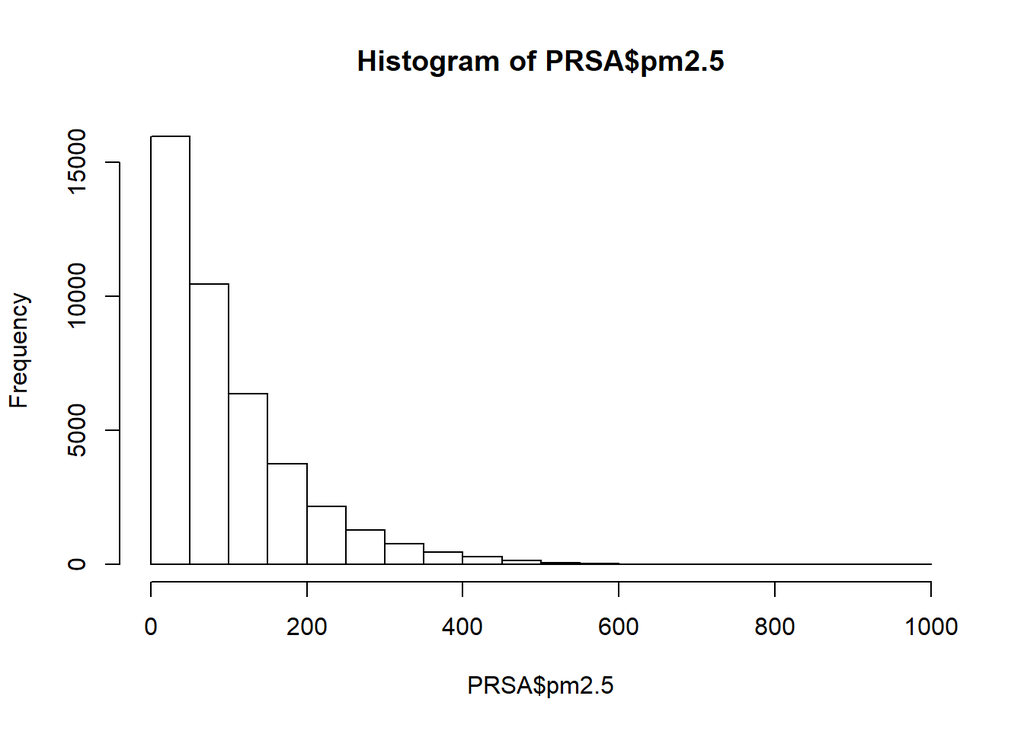

```r
PRSA <- read.csv('PRSA_data.csv')
PRSA <- na.omit(PRSA)

PRSA <- PRSA[-1]
PRSA_train <- PRSA %>% filter(year < 2014)
PRSA_test <- PRSA %>% filter(year == 2014)

hist(PRSA$pm2.5)
```

```r
summary(PRSA$pm2.5)
```

```
##    Min. 1st Qu.  Median    Mean 3rd Qu.    Max.
##    0.00   29.00   72.00   98.61  137.00  994.00
```

데이터를 읽고, 주어진 조건에 따라서 NA가 있는 행은 삭제했다.

또한 1열은 번호를 의미하는 것으로 특별한 의미가 없는 열이라고 판단하여 삭제하고, 작업을 시작했다.

그리고 히스토그램을 통해 볼 수 있듯이 전반적으로 미세먼지가 200보다 작은 데이터가 굉장히 많은 것을 확인할 수 있었다.

# Setting variable

```r
data_2010 <- PRSA %>% filter(year == 2010)
data_2011 <- PRSA %>% filter(year == 2011)
data_2012 <- PRSA %>% filter(year == 2012)
data_2013 <- PRSA %>% filter(year == 2013)

data_2010 <- unite(data_2010, Date, year, month, day, hour, sep = '-')
data_2010$Date <- ymd_h(data_2010$Date)

data_2011 <- unite(data_2011, Date, year, month, day, hour, sep = '-')
data_2011$Date <- ymd_h(data_2011$Date)

data_2012 <- unite(data_2012, Date, year, month, day, hour, sep = '-')
data_2012$Date <- ymd_h(data_2012$Date)

data_2013 <- unite(data_2013, Date, year, month, day, hour, sep = '-')
data_2013$Date <- ymd_h(data_2013$Date)

PRSA_month1 <- PRSA_train %>% filter(month == 1)
PRSA_month2 <- PRSA_train %>% filter(month == 2)
PRSA_month3 <- PRSA_train %>% filter(month == 3)
PRSA_month4 <- PRSA_train %>% filter(month == 4)
PRSA_month5 <- PRSA_train %>% filter(month == 5)
PRSA_month6 <- PRSA_train %>% filter(month == 6)
PRSA_month7 <- PRSA_train %>% filter(month == 7)
PRSA_month8 <- PRSA_train %>% filter(month == 8)
PRSA_month9 <- PRSA_train %>% filter(month == 9)
PRSA_month10 <- PRSA_train %>% filter(month == 10)
PRSA_month11 <- PRSA_train %>% filter(month == 11)
PRSA_month12 <- PRSA_train %>% filter(month == 12)

PRSA_month1 <- unite(PRSA_month1, Date, year, month, day, hour, sep = '-')
PRSA_month1$Date <- ymd_h(PRSA_month1$Date)

PRSA_month2 <- unite(PRSA_month2, Date, year, month, day, hour, sep = '-')
PRSA_month2$Date <- ymd_h(PRSA_month2$Date)

PRSA_month3 <- unite(PRSA_month3, Date, year, month, day, hour, sep = '-')
PRSA_month3$Date <- ymd_h(PRSA_month3$Date)

PRSA_month4 <- unite(PRSA_month4, Date, year, month, day, hour, sep = '-')
PRSA_month4$Date <- ymd_h(PRSA_month4$Date)

PRSA_month5 <- unite(PRSA_month5, Date, year, month, day, hour, sep = '-')
PRSA_month5$Date <- ymd_h(PRSA_month5$Date)

PRSA_month6 <- unite(PRSA_month6, Date, year, month, day, hour, sep = '-')
PRSA_month6$Date <- ymd_h(PRSA_month6$Date)

PRSA_month7 <- unite(PRSA_month7, Date, year, month, day, hour, sep = '-')
PRSA_month7$Date <- ymd_h(PRSA_month7$Date)

PRSA_month8 <- unite(PRSA_month8, Date, year, month, day, hour, sep = '-')
PRSA_month8$Date <- ymd_h(PRSA_month8$Date)

PRSA_month9 <- unite(PRSA_month9, Date, year, month, day, hour, sep = '-')
PRSA_month9$Date <- ymd_h(PRSA_month9$Date)

PRSA_month10 <- unite(PRSA_month10, Date, year, month, day, hour, sep = '-')
PRSA_month10$Date <- ymd_h(PRSA_month10$Date)

PRSA_month11 <- unite(PRSA_month11, Date, year, month, day, hour, sep = '-')
PRSA_month11$Date <- ymd_h(PRSA_month11$Date)

PRSA_month12 <- unite(PRSA_month12, Date, year, month, day, hour, sep = '-')
PRSA_month12$Date <- ymd_h(PRSA_month12$Date)

PRSA <- unite(PRSA, Date, year, month, day, hour, sep = '-')
PRSA$Date <- ymd_h(PRSA$Date)

PRSA_train <- PRSA %>% filter(Date < as.Date('2014-01-01'))
PRSA_test <- PRSA %>% filter(Date >= as.Date('2014-01-01'))
```

이후 작업에서 사용하도록 변수들을 설정했다.

문제에서 주어진 조건에 따라 2010년~2013년까지는 학습 데이터로, 2014년은 테스트 데이터로 설정했다.

또한 연도 및 월별 값 비교를 위하여 연도 및 월별로 새로운 데이터 프레임을 만들었다.

그리고 year, month, day, hour는 시간과 관련된 데이터 이므로 Date라는 하나의 변수로 통일시켰다.

# Q1

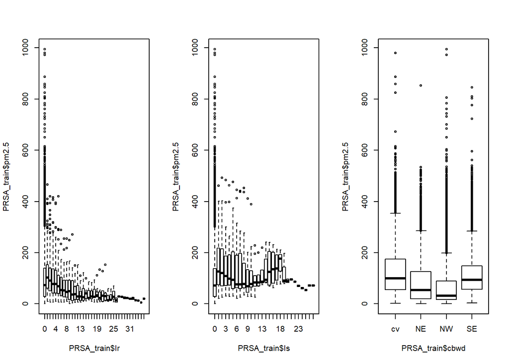

```r
par(mfrow = c(1, 3))
boxplot(PRSA_train$pm2.5~PRSA_train$Ir)
boxplot(PRSA_train$pm2.5~PRSA_train$Is)
boxplot(PRSA_train$pm2.5~PRSA_train$cbwd)
```

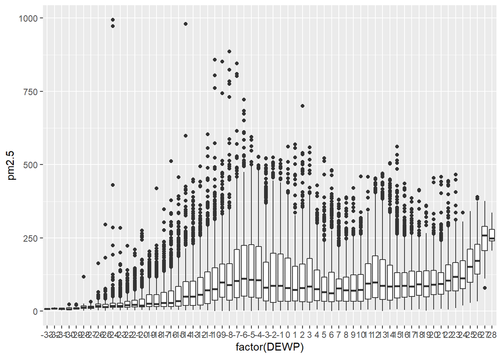

```r
ggplot(PRSA_train, aes(x = factor(DEWP), y = pm2.5)) + geom_boxplot()
```

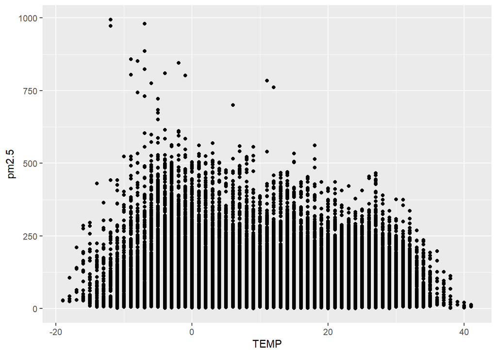

```r
ggplot(PRSA_train, aes(x = TEMP, y = pm2.5)) + geom_point()
```

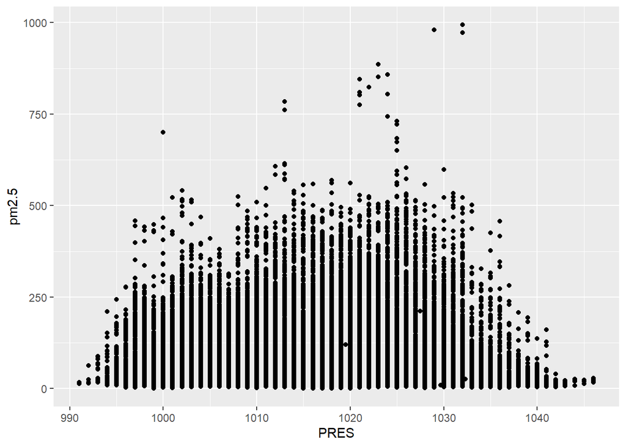

```r
ggplot(PRSA_train, aes(x = PRES, y = pm2.5)) + geom_point()
```

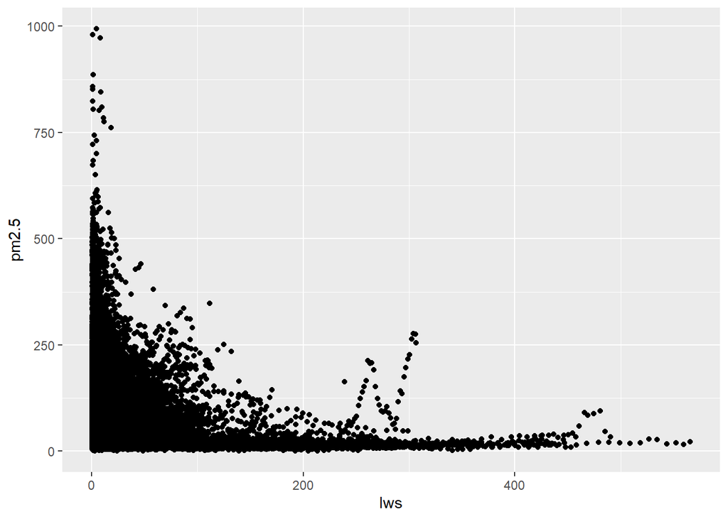

```r
ggplot(PRSA_train, aes(x = Iws, y = pm2.5)) + geom_point()
```

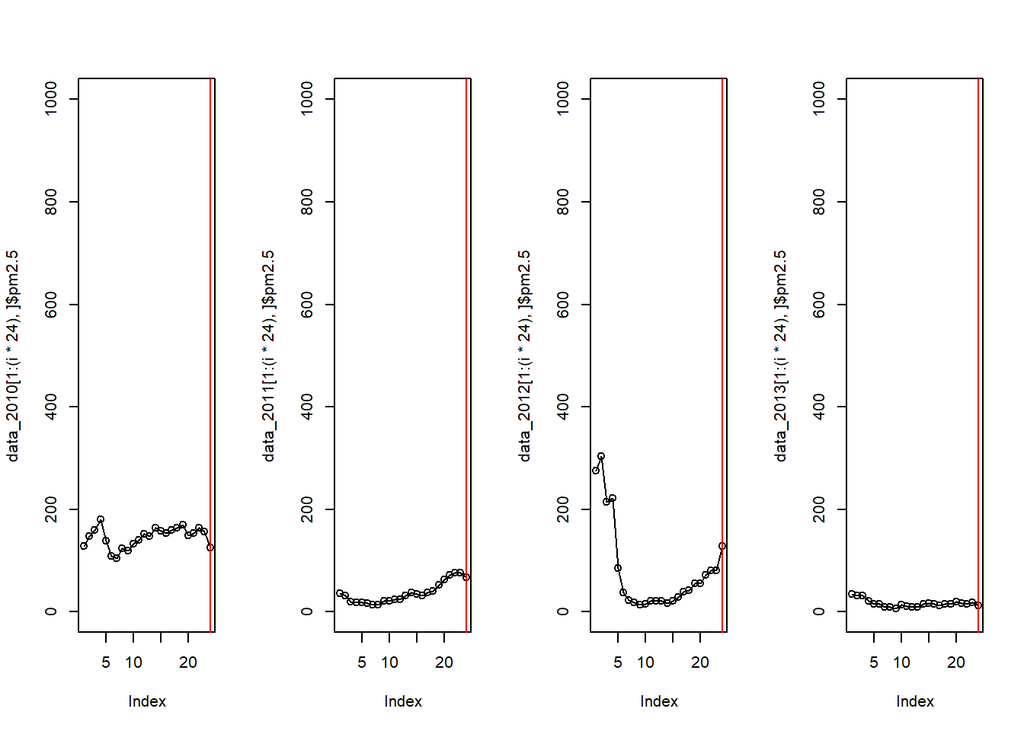

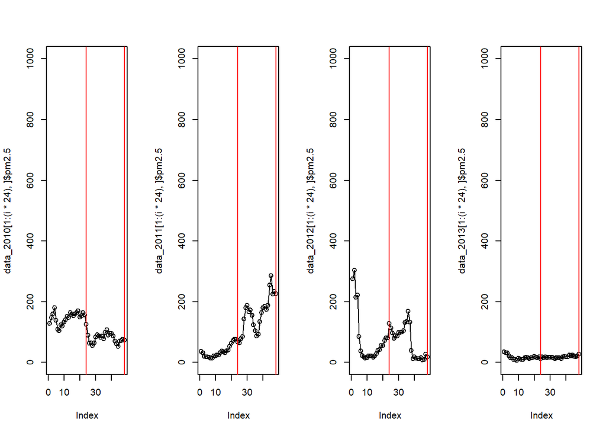

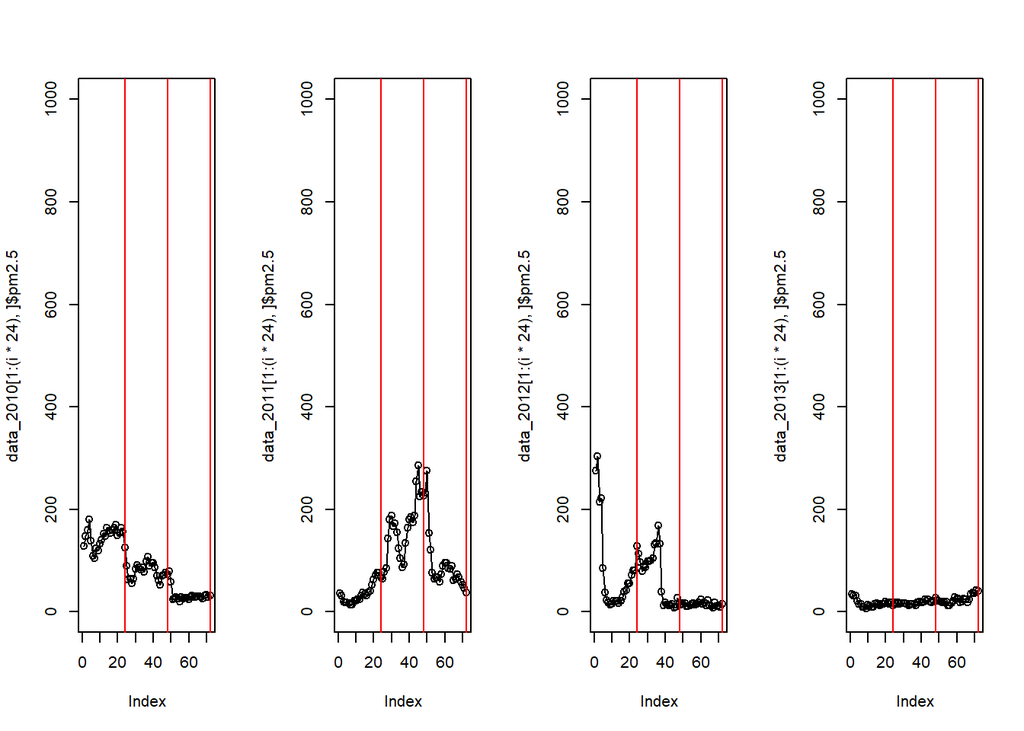

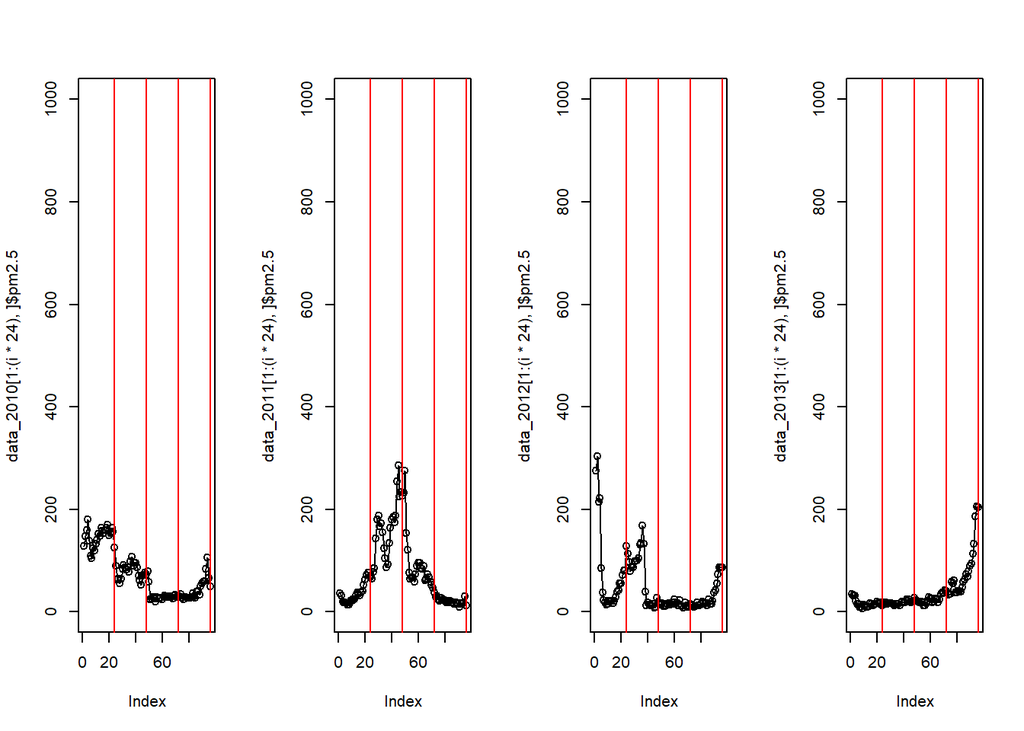

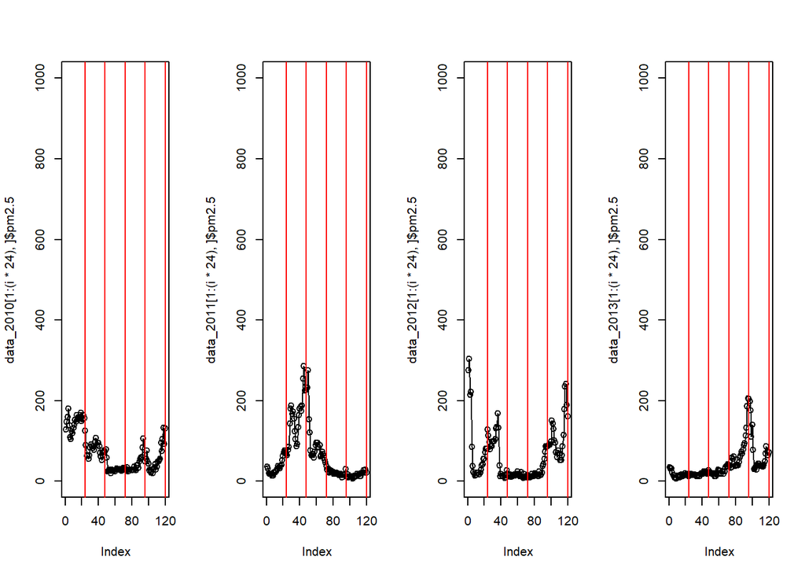

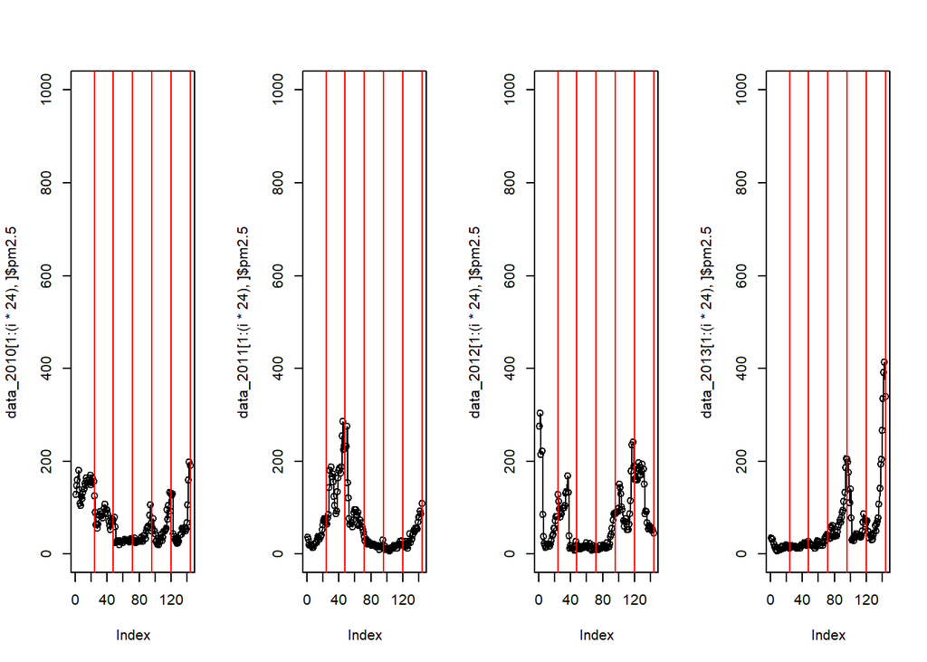

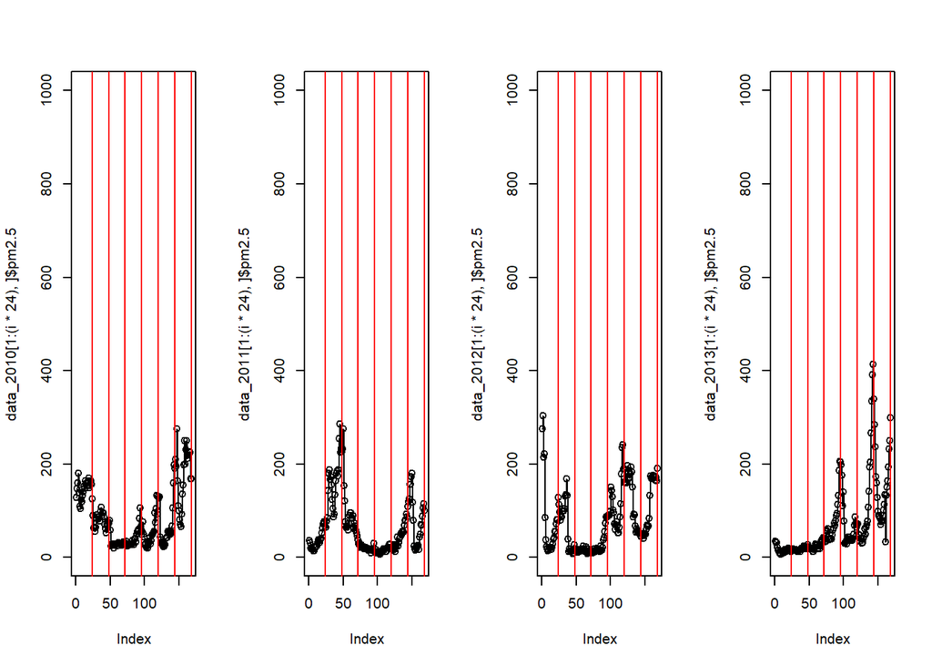

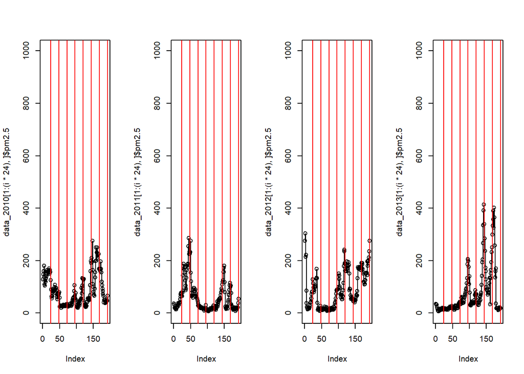

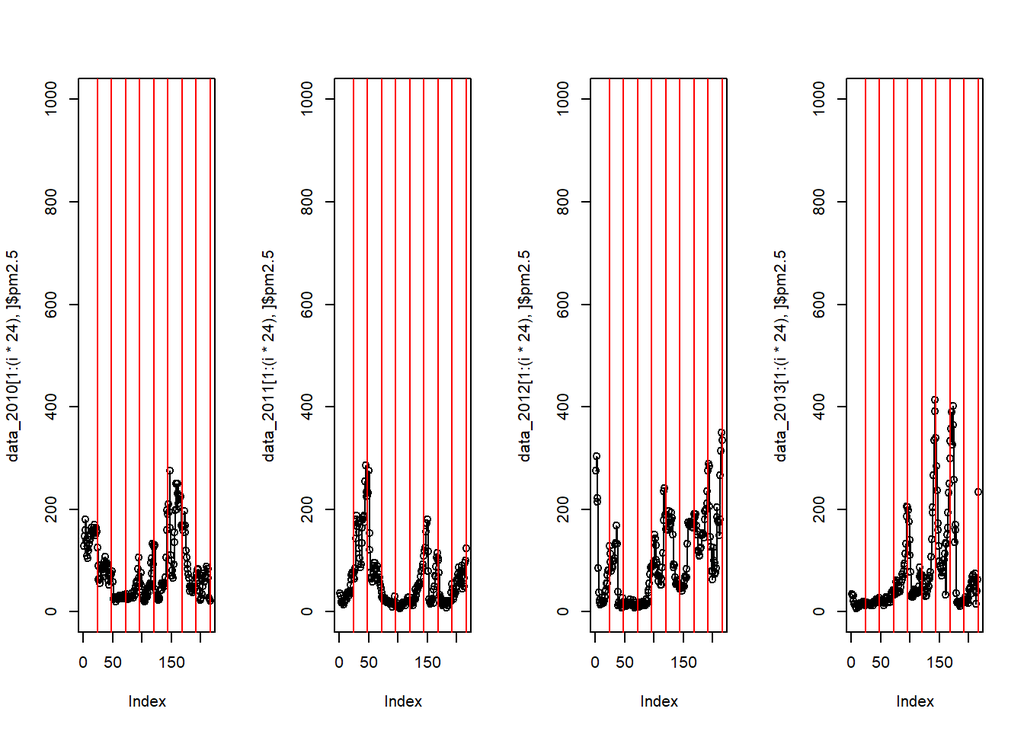

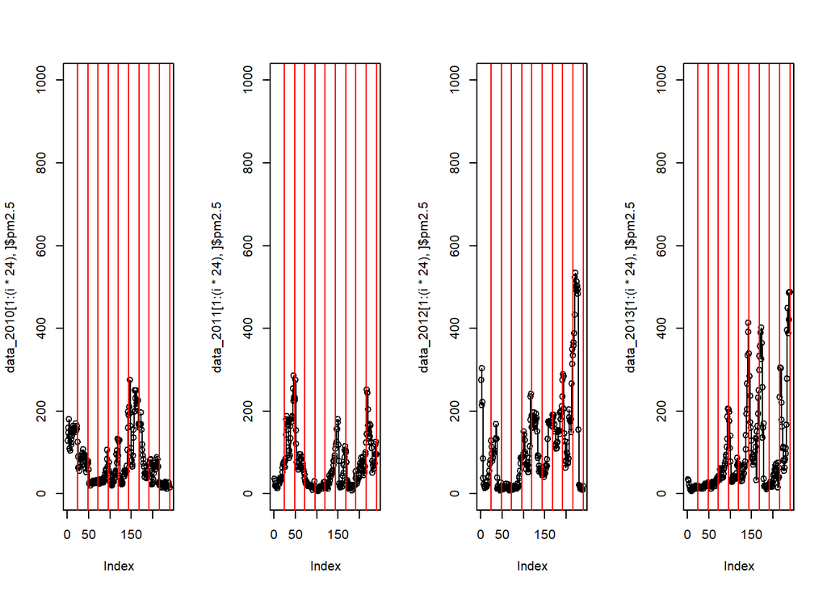

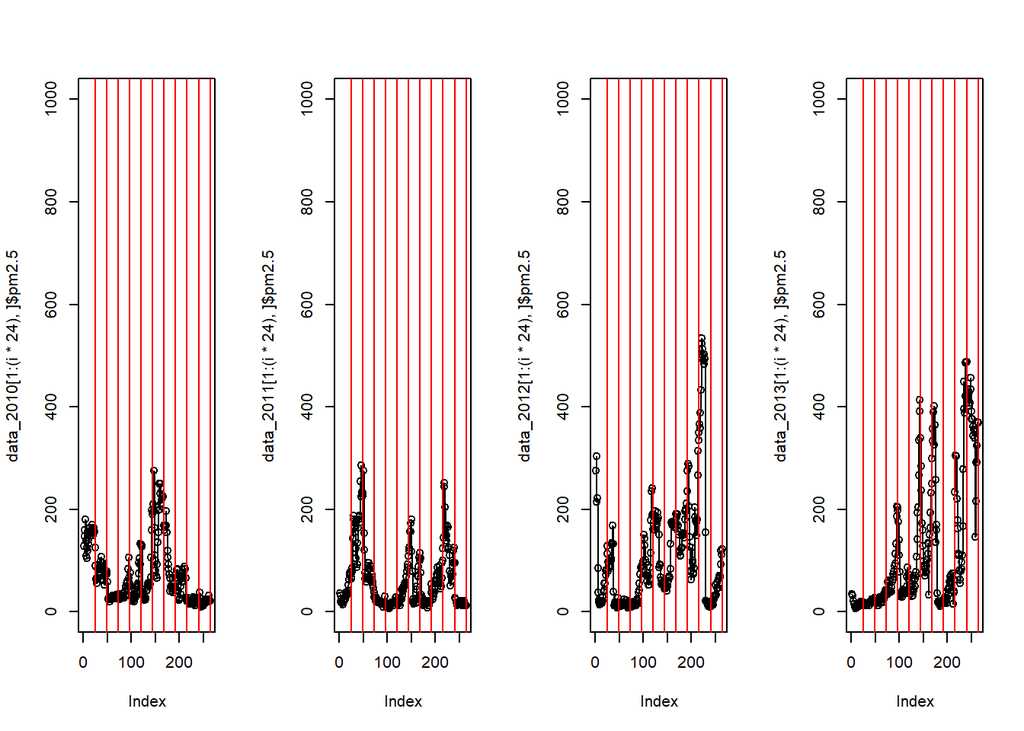

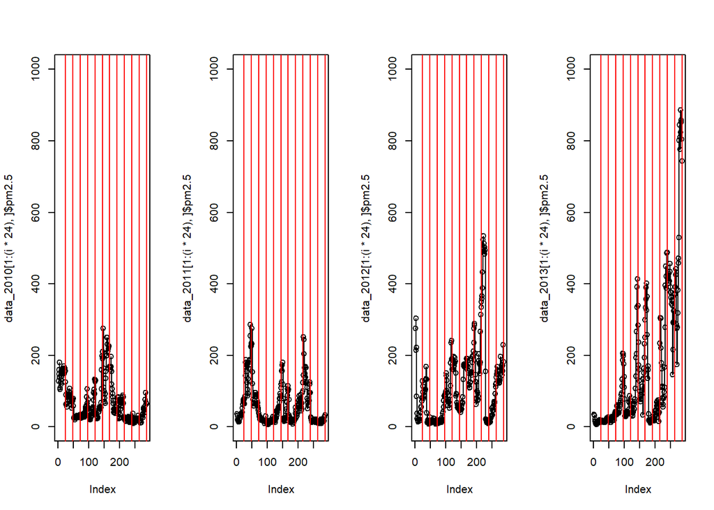

[8 more figures not shown]

```r
data <- 0
par(mfrow = c(1, 4))
for(i in (1:20)){
  data[i] <- 24 * i
  plot(data_2010[1:(i*24), ]$pm2.5, ylim = c(0, 1000)) + lines(data_2010[1:(i*24), ]$pm2.5) +
    abline(v = c(data), col = 'red')

  plot(data_2011[1:(i*24), ]$pm2.5, ylim = c(0, 1000)) + lines(data_2011[1:(i*24), ]$pm2.5) +
    abline(v = c(data), col = 'red')

  plot(data_2012[1:(i*24), ]$pm2.5, ylim = c(0, 1000)) + lines(data_2012[1:(i*24), ]$pm2.5) +
    abline(v = c(data), col = 'red')

  plot(data_2013[1:(i*24), ]$pm2.5, ylim = c(0, 1000)) + lines(data_2013[1:(i*24), ]$pm2.5) +
    abline(v = c(data), col = 'red')
}
```

1) Ir이 0 일때 미세먼지 수치가 월등히 높은 아웃라이어들이 많이 있다.

2. Is 역시 Ir과 비슷하게 0일때 미세먼지 수치가 월등히 높은 아웃라이어들이 많이 있었다.
3. cbwd를 기준으로 전반적인 값들과 차이를 보이는 아웃라이어들이 많이 보였다.
4. DEWP를 기준으로 박스플랏을 그려보면, 이 역시도 전반적 값들과 차이를 보이는 아웃라이어들이 꽤 있었다. 하지만 그 아웃라이어 값들을 제외하면, 전반적으로 이슬점이 낮을때는 농도의 수치가 낮았음을 볼 수 있었다. 또한 상대적으로 이슬점이 높으면, 농도의 수치가 높았음을 확인할 수 있다.
5. TEMP를 기준으로 산점도를 그려면, 전반적인 분포를 알 수는 있지만 특별한 구분점을 찾기는 힘들었다.
6. PRES 역시 산점도를 통해 볼 수 있듯이 특별한 구분점은 찾기 힘들었다. 다만 PRES가 굉장히 낮고, 높은 점에 대해서는 농도의 수치가 낮았음은 눈여겨 볼만 하다.
7. Iws를 기준으로 산점도를 그려보면, 거의 대부분의 점들이 Iws가 200 이하인 점에 분포하고 있음을 알 수 있다.
8. 각 연도를 기준으로 1월달의 일부 수치 변화를 비교하면, 점점 그 수치들의 커지고 있음을 볼 수 있다.
9. 또한 각 데이터에서 갑작스럽게 급격히 증가하는 점들이 종종 발생하는 것을 볼 수 있다.
10. 이에 따라 미세먼지라는 요소가 주어진 환경 데이터 안에서만 영향을 받는 것이 아니라, 공장의 확장이나 자동차 수의 증가와 같은 비환경적 요인에 의한 영향이 있을 수도 있겠다. 이 가설이 연도가 지날수록 미세먼지 수치가 점점 더 높아지는 이유가 될 수도 있겠다. 더 자세한 부분은 주어진 데이터를 더욱 분석하여 결론을 얻을 수 있을 것이다.

```r
par(mfrow = c(2, 3))
plot(PRSA_month1$pm2.5, pch = 1, cex = 0.5, ylim = c(0, 980), main = "1월") +
  lines(PRSA_month1$pm2.5) + abline(h = mean(PRSA_month1$pm2.5), v = c(654, 1326, 1996),
                                    col = c('blue', 'red', 'red', 'red'))
```

```
## integer(0)
```

```r
plot(PRSA_month2$pm2.5, pch = 1, cex = 0.5, ylim = c(0, 980), main = "2월") +
  lines(PRSA_month2$pm2.5) + abline(h = mean(PRSA_month2$pm2.5), v = c(672, 1344, 2034),
                                    col = c('blue', 'red', 'red', 'red'))
```

```
## integer(0)
```

```r
plot(PRSA_month3$pm2.5, pch = 1, cex = 0.5, ylim = c(0, 980), main = "3월") +
  lines(PRSA_month3$pm2.5) + abline(h = mean(PRSA_month3$pm2.5), v = c(710, 1335, 2075),
                                    col = c('blue', 'red', 'red', 'red'))
```

```
## integer(0)
```

```r
plot(PRSA_month10$pm2.5, pch = 1, cex = 0.5, ylim = c(0, 980), main = "10월") +
  lines(PRSA_month10$pm2.5) + abline(h = mean(PRSA_month10$pm2.5), v = c(742, 1359, 2099),
                                     col = c('blue', 'red', 'red', 'red'))
```

```
## integer(0)
```

```r
plot(PRSA_month11$pm2.5, pch = 1, cex = 0.5, ylim = c(0, 980), main = "11월") +
  lines(PRSA_month11$pm2.5) + abline(h = mean(PRSA_month11$pm2.5), v = c(665, 1380, 2078),
                                     col = c('blue', 'red', 'red', 'red'))
```

```
## integer(0)
```

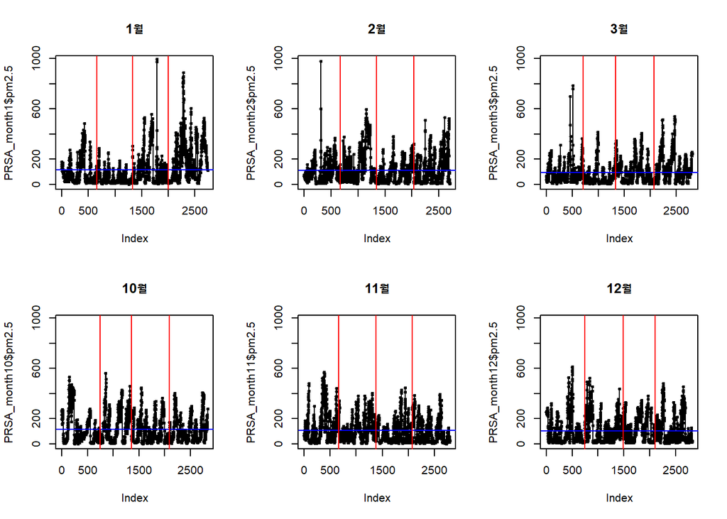

```
## integer(0)
```

```r
plot(PRSA_month12$pm2.5, pch = 1, cex = 0.5, ylim = c(0, 980), main = "12월") +
  lines(PRSA_month12$pm2.5) + abline(h = mean(PRSA_month12$pm2.5), v = c(745, 1488, 2102),
                                     col = c('blue', 'red', 'red', 'red'))
```

2010~2013년까지 월별로 나뉜 데이터 프레임을 사용한다.

날짜 별로 순서대로 미세먼지 농도를 plot으로 그리고, 그에 대하여 연도 기준선을 빨간색으로, 그 데이터 프레임의 평균을 파란색으로 표시했다.

11. 비교적 농도가 높았던 1, 2, 3, 10, 11, 12월의 정보를 보면, 평균값에 비해 차이가 월등히 나는 점들이 너무 많아서 단편적으로 월 별 평균으로 접근하기엔 Error 값이 클 것이라고 생각했다.

```r
par(mfrow = c(2, 3))
plot(PRSA_month4$pm2.5, pch = 1, cex = 0.5, ylim = c(0, 980), main = "4월") +
  lines(PRSA_month4$pm2.5) + abline(h = mean(PRSA_month4$pm2.5), v = c(719, 1255, 1974),
                                    col = c('blue', 'red', 'red', 'red'))
```

```
## integer(0)
```

```r
plot(PRSA_month5$pm2.5, pch = 1, cex = 0.5, ylim = c(0, 980), main = "5월") +
  lines(PRSA_month5$pm2.5) + abline(h = mean(PRSA_month5$pm2.5), v = c(738, 1450, 2141),
                                    col = c('blue', 'red', 'red', 'red'))
```

```
## integer(0)
```

```r
plot(PRSA_month6$pm2.5, pch = 1, cex = 0.5, ylim = c(0, 980), main = "6월") +
  lines(PRSA_month6$pm2.5) + abline(h = mean(PRSA_month6$pm2.5), v = c(566, 1277, 1985),
                                    col = c('blue', 'red', 'red', 'red'))
```

```
## integer(0)
```

```r
plot(PRSA_month7$pm2.5, pch = 1, cex = 0.5, ylim = c(0, 980), main = "7월") +
  lines(PRSA_month7$pm2.5) + abline(h = mean(PRSA_month7$pm2.5), v = c(745, 1486, 2174),
                                    col = c('blue', 'red', 'red', 'red'))
```

```
## integer(0)
```

```r
plot(PRSA_month8$pm2.5, pch = 1, cex = 0.5, ylim = c(0, 980), main = "8월") +
  lines(PRSA_month8$pm2.5) + abline(h = mean(PRSA_month8$pm2.5), v = c(677, 1247, 1870),
                                    col = c('blue', 'red', 'red', 'red'))
```

```
## integer(0)
```

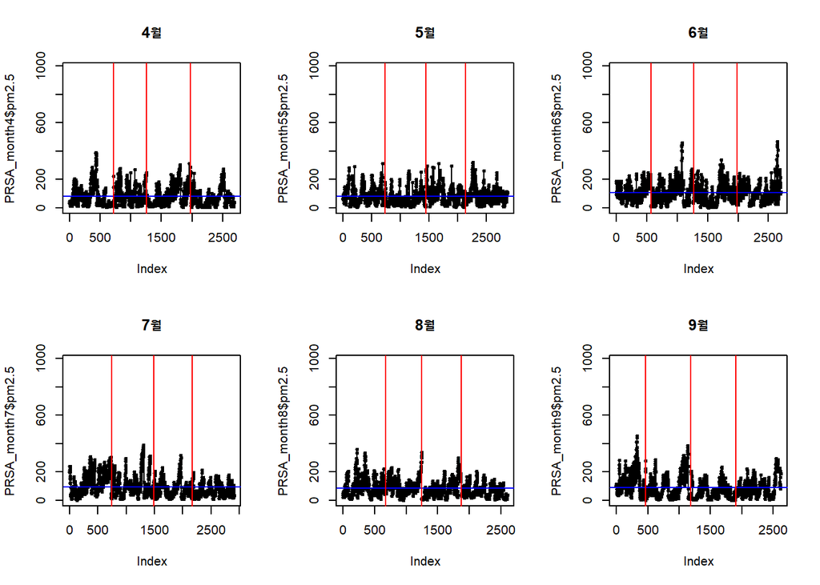

```
## integer(0)
```

```r
plot(PRSA_month9$pm2.5, pch = 1, cex = 0.5, ylim = c(0, 980), main = "9월") +
  lines(PRSA_month9$pm2.5) + abline(h = mean(PRSA_month9$pm2.5), v = c(469, 1188, 1902),
                                    col = c('blue', 'red', 'red', 'red'))
```

12. 비교적 농도가 낮았던 4, 5, 6, 7, 8, 9월의 정보를 보면, 일부 아웃라이어 값이 있긴 하지만, 앞선 농도가 높았던 월들에 비해서는 평균값과 대부분의 값이 비슷하여 그나마 이 달에서는 적용이 될 수도 있겠다고 생각했다.

```r
par(mfrow = c(1, 2))
plot(PRSA_month1$pm2.5, pch = 16, cex = 0.8, ylim = c(0, 980), main = "1월") +
  lines(PRSA_month1$pm2.5) + abline(h = mean(PRSA_month1$pm2.5), v = c(654, 1326, 1996),
                                    col = c('blue', 'red', 'red', 'red'))
```

```
## integer(0)
```

```r
par(new = TRUE)
plot(PRSA_month1$Iws, pch = 1, cex = 0.3, ylim = c(0, 500)) + lines(PRSA_month1$Iws, col = 'yellow')
```

```
## integer(0)
```

```r
par(new = TRUE)
plot(PRSA_month1$Ir, pch = 1, cex = 0.3) + lines(PRSA_month1$Ir, col = 'pink')
```

```
## integer(0)
```

```r
plot(PRSA_month2$pm2.5, pch = 16, cex = 0.8, ylim = c(0, 980), main = "2월") +
  lines(PRSA_month2$pm2.5) + abline(h = mean(PRSA_month2$pm2.5), v = c(672, 1344, 2034),
                                    col = c('blue', 'red', 'red', 'red'))
```

```
## integer(0)
```

```r
par(new = TRUE)
plot(PRSA_month2$Iws, pch = 1, cex = 0.3, ylim = c(0, 500)) + lines(PRSA_month2$Iws, col = 'yellow')
```

```
## integer(0)
```

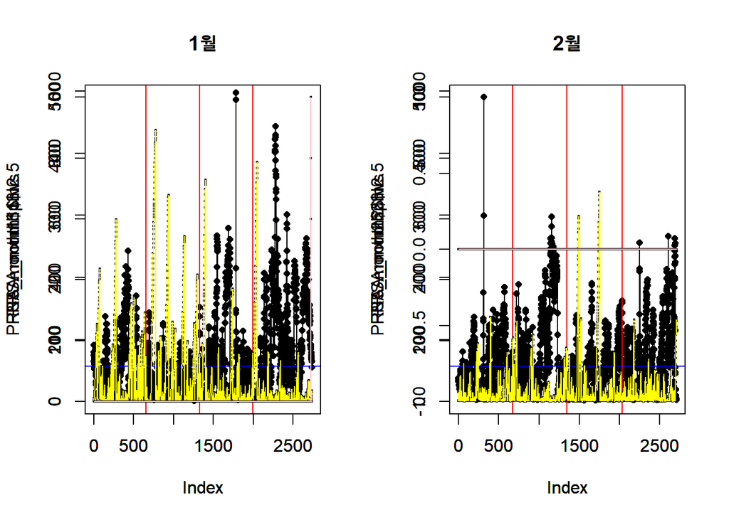

```
## integer(0)
```

```r
par(new = TRUE)
plot(PRSA_month2$Ir, pch = 1, cex = 0.3) + lines(PRSA_month2$Ir, col = 'pink')
```

```r
plot(PRSA_month3$pm2.5, pch = 16, cex = 0.8, ylim = c(0, 980), main = "3월") +
  lines(PRSA_month3$pm2.5) + abline(h = mean(PRSA_month3$pm2.5), v = c(710, 1335, 2075),
                                    col = c('blue', 'red', 'red', 'red'))
```

```
## integer(0)
```

```r
par(new = TRUE)
plot(PRSA_month3$Iws, pch = 1, cex = 0.3, ylim = c(0, 500)) + lines(PRSA_month3$Iws, col = 'yellow')
```

```
## integer(0)
```

```r
par(new = TRUE)
plot(PRSA_month3$Ir, pch = 1, cex = 0.3) + lines(PRSA_month3$Ir, col = 'pink')
```

```
## integer(0)
```

```r
plot(PRSA_month4$pm2.5, pch = 16, cex = 0.8, ylim = c(0, 980), main = "4월") +
  lines(PRSA_month4$pm2.5, ) + abline(h = mean(PRSA_month4$pm2.5), v = c(719, 1255, 1974),
                                    col = c('blue', 'red', 'red', 'red'))
```

```
## integer(0)
```

```r
par(new = TRUE)
plot(PRSA_month4$Iws, pch = 1, cex = 0.3, ylim = c(0, 500)) + lines(PRSA_month4$Iws, col = 'yellow')
```

```
## integer(0)
```

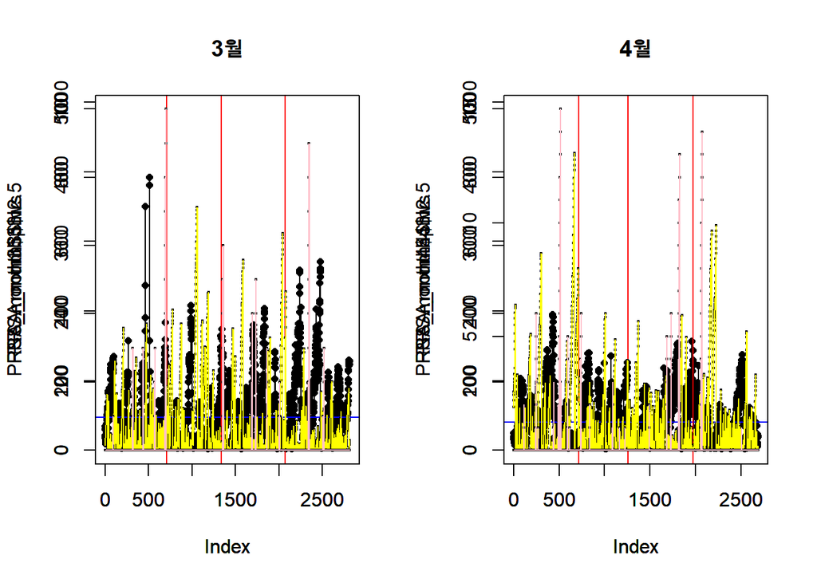

```
## integer(0)
```

```r
par(new = TRUE)
plot(PRSA_month4$Ir, pch = 1, cex = 0.3) + lines(PRSA_month4$Ir, col = 'pink')
```

```r
plot(PRSA_month5$pm2.5, pch = 16, cex = 0.8, ylim = c(0, 980), main = "5월") +
  lines(PRSA_month5$pm2.5) + abline(h = mean(PRSA_month5$pm2.5), v = c(738, 1450, 2141),
                                    col = c('blue', 'red', 'red', 'red'))
```

```
## integer(0)
```

```r
par(new = TRUE)
plot(PRSA_month5$Iws, pch = 1, cex = 0.3, ylim = c(0, 500)) + lines(PRSA_month5$Iws, col = 'yellow')
```

```
## integer(0)
```

```r
par(new = TRUE)
plot(PRSA_month5$Ir, pch = 1, cex = 0.3) + lines(PRSA_month5$Ir, col = 'pink')
```

```
## integer(0)
```

```r
plot(PRSA_month6$pm2.5, pch = 16, cex = 0.8, ylim = c(0, 980), main = "6월") +
  lines(PRSA_month6$pm2.5) + abline(h = mean(PRSA_month6$pm2.5), v = c(566, 1277, 1985),
                                    col = c('blue', 'red', 'red', 'red'))
```

```
## integer(0)
```

```r
par(new = TRUE)
plot(PRSA_month6$Iws, pch = 1, cex = 0.3, ylim = c(0, 500)) + lines(PRSA_month6$Iws, col = 'yellow')
```

```
## integer(0)
```

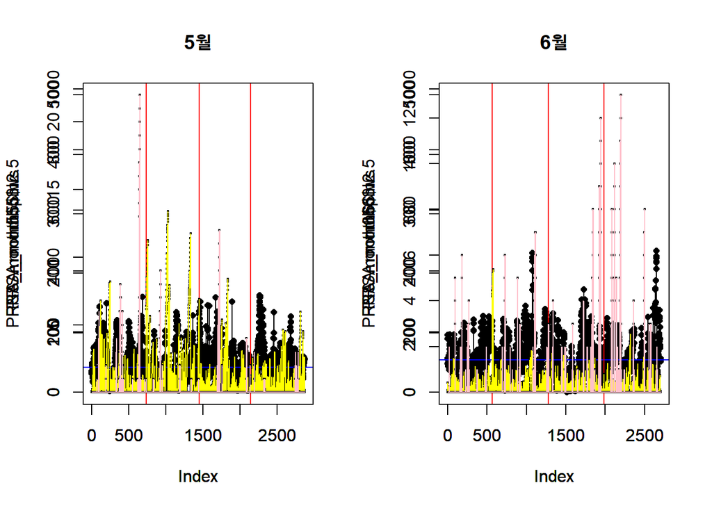

```
## integer(0)
```

```r
par(new = TRUE)
plot(PRSA_month6$Ir, pch = 1, cex = 0.3) + lines(PRSA_month6$Ir, col = 'pink')
```

```r
plot(PRSA_month7$pm2.5, pch = 16, cex = 0.8, ylim = c(0, 980), main = "7월") +
  lines(PRSA_month7$pm2.5) + abline(h = mean(PRSA_month7$pm2.5), v = c(745, 1486, 2174),
                                    col = c('blue', 'red', 'red', 'red'))
```

```
## integer(0)
```

```r
par(new = TRUE)
plot(PRSA_month7$Iws, pch = 1, cex = 0.3, ylim = c(0, 500)) + lines(PRSA_month7$Iws, col = 'yellow')
```

```
## integer(0)
```

```r
par(new = TRUE)
plot(PRSA_month7$Ir, pch = 1, cex = 0.3) + lines(PRSA_month7$Ir, col = 'pink')
```

```
## integer(0)
```

```r
plot(PRSA_month8$pm2.5, pch = 16, cex = 0.8, ylim = c(0, 980), main = "8월") +
  lines(PRSA_month8$pm2.5) + abline(h = mean(PRSA_month8$pm2.5), v = c(677, 1247, 1870),
                                    col = c('blue', 'red', 'red', 'red'))
```

```
## integer(0)
```

```r
par(new = TRUE)
plot(PRSA_month8$Iws, pch = 1, cex = 0.3, ylim = c(0, 500)) + lines(PRSA_month8$Iws, col = 'yellow')
```

```
## integer(0)
```

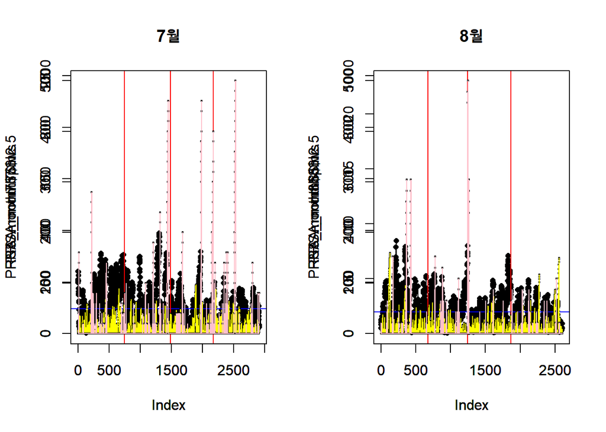

```
## integer(0)
```

```r
par(new = TRUE)
plot(PRSA_month8$Ir, pch = 1, cex = 0.3) + lines(PRSA_month8$Ir, col = 'pink')
```

```r
plot(PRSA_month9$pm2.5, pch = 16, cex = 0.8, ylim = c(0, 980), main = "9월") +
  lines(PRSA_month9$pm2.5) + abline(h = mean(PRSA_month9$pm2.5), v = c(469, 1188, 1902),
                                    col = c('blue', 'red', 'red', 'red'))
```

```
## integer(0)
```

```r
par(new = TRUE)
plot(PRSA_month9$Iws, pch = 1, cex = 0.3, ylim = c(0, 500)) + lines(PRSA_month9$Iws, col = 'yellow')
```

```
## integer(0)
```

```r
par(new = TRUE)
plot(PRSA_month9$Ir, pch = 1, cex = 0.3) + lines(PRSA_month9$Ir, col = 'pink')
```

```
## integer(0)
```

```r
plot(PRSA_month10$pm2.5, pch = 16, cex = 0.8, ylim = c(0, 980), main = "10월") +
  lines(PRSA_month10$pm2.5) + abline(h = mean(PRSA_month10$pm2.5), v = c(742, 1359, 2099),
                                     col = c('blue', 'red', 'red', 'red'))
```

```
## integer(0)
```

```r
par(new = TRUE)
plot(PRSA_month10$Iws, pch = 1, cex = 0.3, ylim = c(0, 500)) + lines(PRSA_month10$Iws, col = 'yellow')
```

```
## integer(0)
```

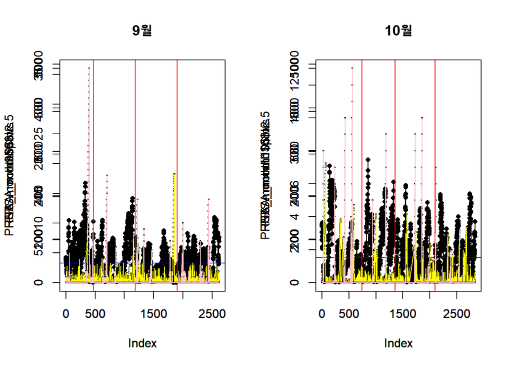

```
## integer(0)
```

```r
par(new = TRUE)
plot(PRSA_month10$Ir, pch = 1, cex = 0.3) + lines(PRSA_month10$Ir, col = 'pink')
```

```r
plot(PRSA_month11$pm2.5, pch = 16, cex = 0.8, ylim = c(0, 980), main = "11월") +
  lines(PRSA_month11$pm2.5) + abline(h = mean(PRSA_month11$pm2.5), v = c(665, 1380, 2078),
                                     col = c('blue', 'red', 'red', 'red'))
```

```
## integer(0)
```

```r
par(new = TRUE)
plot(PRSA_month11$Iws, pch = 1, cex = 0.3, ylim = c(0, 500)) + lines(PRSA_month11$Iws, col = 'yellow')
```

```
## integer(0)
```

```r
par(new = TRUE)
plot(PRSA_month11$Ir, pch = 1, cex = 0.3) + lines(PRSA_month11$Ir, col = 'pink')
```

```
## integer(0)
```

```r
plot(PRSA_month12$pm2.5, pch = 16, cex = 0.8, ylim = c(0, 980), main = "12월") +
  lines(PRSA_month12$pm2.5) + abline(h = mean(PRSA_month12$pm2.5), v = c(745, 1488, 2102),
                                     col = c('blue', 'red', 'red', 'red'))
```

```
## integer(0)
```

```r
par(new = TRUE)
plot(PRSA_month12$Iws, pch = 1, cex = 0.3, ylim = c(0, 500)) + lines(PRSA_month12$Iws, col = 'yellow')
```

```
## integer(0)
```

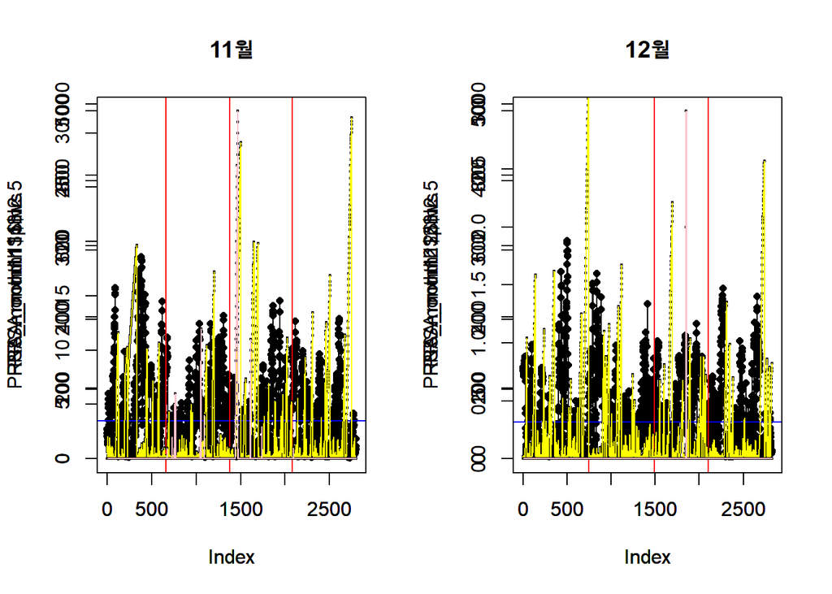

```
## integer(0)
```

```r
par(new = TRUE)
plot(PRSA_month12$Ir, pch = 1, cex = 0.3) + lines(PRSA_month12$Ir, col = 'pink')
```

13. 그리고 2개월 단위씩 기존에 그렸던 미세먼지 수치 그래프에 Iws와 Ir 변수를 추가해서 함께 본다. 기존의 검정색 점과 선은 월별 미세먼지를 보인 것이고, 노란색은 Iws, 핑크색은 Ir 변수의 값들이다. plot 안에 있는 연속형 변수들이 미세먼지 농도와 비슷한 수치나 흐름 등을 보이길 바랬지만, 전반적인 유사한 특징들은 보이지 않았다.

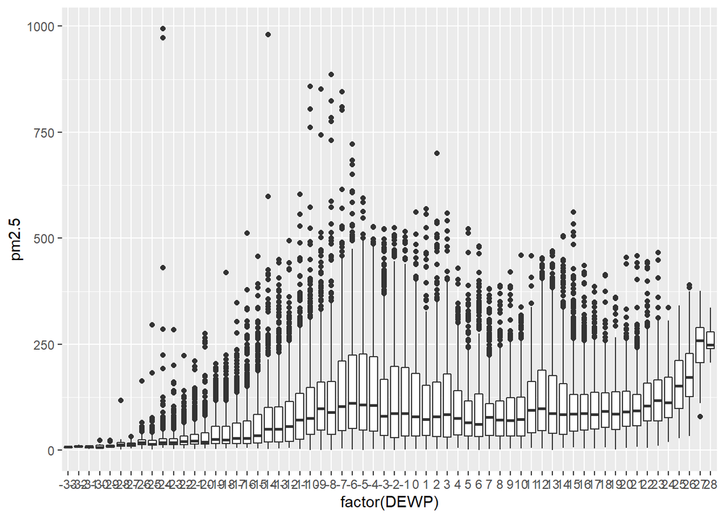

```r
ggplot(PRSA_train, aes(x = factor(DEWP), y = pm2.5)) + geom_boxplot()
```

다음의 과정들을 통해서 전반적인 데이터의 분포나 특징들을 일반화시키고자 하는 노력들을 했지만, 대부분의 경우에서 R square 값 등이 낮은 수치를 보였다. 그래서 결국 다시 처음으로 돌아와서 일반 변수 중에서 그나마 전반적 형태가 보기 쉬웠던 이슬점 변수를 기준으로 다시 접근해보았다.

이슬점 수치가 낮을수록 농도가 낮았고, 물론 아웃라이어 값이 있긴 했지만, 이슬점 수치가 높을수록 농도가 비교적 높았다.

# Q2, Q3

#Modeling_train

```r
PRSA_train <- merge(PRSA_train, aggregate(pm2.5~DEWP, PRSA_train, median), by = 'DEWP')

colnames(PRSA_train)[3] <- 'pm2.5'
colnames(PRSA_train)[10] <- 'pm2.5_median'

summary(PRSA_train$pm2.5_median)
```

```
##    Min. 1st Qu.  Median    Mean 3rd Qu.    Max.
##    6.50   65.00   84.00   76.29   93.00  259.00
```

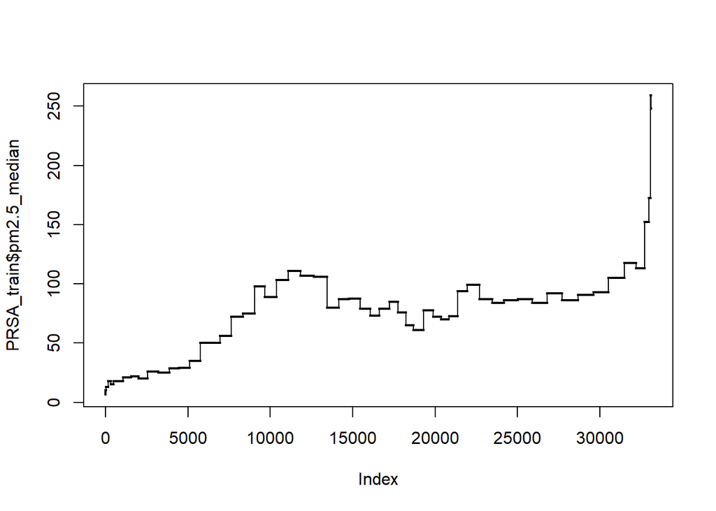

```
## integer(0)
```

```r
plot(PRSA_train$pm2.5_median, cex = 0.3) + lines(PRSA_train$pm2.5_median)
```

```r
PRSA_train$group <- cut(PRSA_train$pm2.5_median, breaks = c(0, 10, 18, 22, 29, 56, 66, 75, 80, 85,
                                                            91, 95, 100, 107, 118, 152, 173, 248, Inf),
                        right = TRUE, labels = c(1:18))

sv_reg_DEWP <- tapply(PRSA_train$pm2.5, PRSA_train$group, mean)
PRSA_train$pred_pm2.5_mean <- sv_reg_DEWP[PRSA_train$group]
PRSA_train$error <- PRSA_train$pm2.5 - PRSA_train$pred_pm2.5_mean
MSE_train_mean <- mean(PRSA_train$error ** 2)
RMSE_train_mean <- sqrt(MSE_train_mean)
RMSE_train_mean
```

```
## [1] 85.89868
```

```r
sd(PRSA_train$pm2.5)
```

```
## [1] 91.65887
```

```r
RSS_mean <- sum(PRSA_train$error ** 2)
SStot_mean <- sum((PRSA_train$pm2.5 - mean(PRSA_train$pm2.5)) ** 2)
Rsq_mean <- 1 - RSS_mean/SStot_mean
Rsq_mean
```

```
## [1] 0.1217117
```

앞서 이야기했듯, 비교적 분류가 쉬운 형태를 보이는 이슬점 변수에 대하여 모델링을 만들어보았다.

모델을 만드는 과정은 다음과 같다. aggregate 함수를 통해서 이슬점 값을 기준으로 미세먼지 농도의 median 값을 구하고, merge 함수를 통해서 기존 train 데이터에 묶었다.

그리고 찾아낸 각 이슬점에 대한 미세먼지의 median 값을 Labeling 시키기 위하여 산점도 및 연결된 직선을 통해서 전반적 분포를 확인했다.

이를 통해 그 차이가 너무 심하지 않는 지점들을 기준으로 cut 함수를 통해서 새롭게 기준 점을 만들어서 group 변수를 만들었다.

이 예측 모델을 통하여 훈련 데이터에서는 RMSE 값이 약 85가 나왔고, 이 값의 표준편차는 91인 것을 확인했다.

따라서 기존 값의 표준편차 보다 작음을 확인할 수 있었고, 이에 대한 R square 값은 약 12% 정도가 되었다.

예측도 자체가 높은 편은 아니지만, 단일 변수 데이터와 비환경적 요소가 포함되어 있지 못하여 이 모델의 한계점이 있는 것으로 판단했다.

# Q4, Q5

#Modeling_test

```r
PRSA_test <- merge(PRSA_test, aggregate(pm2.5~DEWP, PRSA_test, median), by = 'DEWP')

colnames(PRSA_test)[3] <- 'pm2.5'
colnames(PRSA_test)[10] <- 'pm2.5_median'

PRSA_test$group <- cut(PRSA_test$pm2.5_median, breaks = c(0, 10, 18, 22, 29, 56, 66, 75, 80, 85,
                                                          91, 95, 100, 107, 118, 152, 173, 248, Inf),
                       right = TRUE, labels = c(1:18))

sv_reg_DEWP <- tapply(PRSA_train$pm2.5, PRSA_train$group, mean)
PRSA_test$pred_pm2.5 <- sv_reg_DEWP[PRSA_test$group]
PRSA_test$error <- PRSA_test$pm2.5 - PRSA_test$pred_pm2.5
MSE_test <- mean(PRSA_test$error ** 2)
RMSE_test <- sqrt(MSE_test)
RMSE_test
```

```
## [1] 87.40589
```

```r
sd(PRSA_test$pm2.5)
```

```
## [1] 93.53153
```

```r
RSS_test <- sum(PRSA_test$error ** 2)
SStot_test <- sum((PRSA_test$pm2.5 - mean(PRSA_test$pm2.5)) ** 2)
Rsq_test <- 1 - RSS_test/SStot_test
Rsq_test
```

```
## [1] 0.1265954
```

훈련 데이터에 적용시킨 모델을 새롭게 test 데이터에 적용시켜본다.

앞선 과정과 똑같이 이슬점에 대한 미세먼지의 median 값을 기준으로 그룹과 범위를 나누고, 이에 대한 예측도를 평가했다.

그 결과 RMSE는 약 87이 나왔고, 표준편차는 93으로 예측값이 표준편차보다 작았음을 먼저 확인했다.

이후에는 이 모델을 바탕으로 R square 값을 구했고, 이를 통해 약 12% 정도 나왔음을 볼 수 있었다.

train과 test 데이터 모두에서 비슷한 예측도가 나왔으므로 이는 과적합은 아니라고 판단할 수 있다.

# Q6

```r
PRSA_train$pm_delta <- 0
PRSA_train$Iws_delta <- 0

for (i in (1:33095)){
  PRSA_train$pm_delta[i] <- (PRSA_train$pm2.5[(i+1)] - PRSA_train$pm2.5[i]) / PRSA_train$pm2.5[i]
}

for (i in (1:33095)){
  PRSA_train$DEWP_delta[i] <- (PRSA_train$DEWP[(i+1)] - PRSA_train$DEWP[i]) / PRSA_train$DEWP[i]
}

for (i in (1:33095)){
  PRSA_train$Iws_delta[i] <- (PRSA_train$Iws[(i+1)] - PRSA_train$Iws[i]) / PRSA_train$Iws[i]
}

head(PRSA_train, 10)
```

```
##    DEWP                Date pm2.5 TEMP PRES cbwd    Iws Is Ir pm2.5_median
## 1   -33 2013-11-28 12:00:00     9    4 1026   NW 413.03  0  0          7.5
## 2   -33 2013-12-12 14:00:00     6    1 1023   NW  88.06  0  0          7.5
## 3   -32 2013-12-12 13:00:00     8    1 1023   NW  75.99  0  0          9.0
## 4   -32 2013-11-28 11:00:00     9    3 1027   NW 403.20  0  0          9.0
## 5   -32 2013-12-12 15:00:00    13    0 1023   NW  97.00  0  0          9.0
## 6   -31 2013-11-10 02:00:00     3    2 1034   NW  91.17  0  0          9.0
## 7   -31 2013-11-28 13:00:00     9    4 1025   NW 421.97  0  0          9.0
## 8   -31 2013-11-10 11:00:00     9    7 1030   NW 159.57  0  0          9.0
## 9   -30 2013-11-10 12:00:00     5    8 1028   NW 167.62  0  0          6.5
## 10  -30 2013-11-10 10:00:00    14    5 1032   NW 152.42  0  0          6.5
##    group pred_pm2.5_mean      error   pm_delta   Iws_delta  DEWP_delta
## 1      1        9.676471 -0.6764706 -0.3333333 -0.78679515  0.00000000
## 2      1        9.676471 -3.6764706  0.3333333 -0.13706564 -0.03030303
## 3      1        9.676471 -1.6764706  0.1250000  4.30596131  0.00000000
## 4      1        9.676471 -0.6764706  0.4444444 -0.75942460  0.00000000
## 5      1        9.676471  3.3235294 -0.7692308 -0.06010309 -0.03125000
## 6      1        9.676471 -6.6764706  2.0000000  3.62838653  0.00000000
## 7      1        9.676471 -0.6764706  0.0000000 -0.62184515  0.00000000
## 8      1        9.676471 -0.6764706 -0.4444444  0.05044808 -0.03225806
## 9      1        9.676471 -4.6764706  1.8000000 -0.09068130  0.00000000
## 10     1        9.676471  4.3235294 -0.5000000  1.09099856  0.00000000
```

```r
summary(PRSA_train$pm_delta)
```

```
##    Min. 1st Qu.  Median    Mean 3rd Qu.    Max.
## -1.0000 -0.5455  0.0000     Inf  1.2182     Inf
```

```r
summary(PRSA_train$DEWP_delta)
```

```
##    Min. 1st Qu.  Median    Mean 3rd Qu.    Max.    NA's
##      -1       0       0     Inf       0     Inf     615
```

```r
summary(PRSA_train$Iws_delta)
```

```
##     Min.  1st Qu.   Median     Mean  3rd Qu.     Max.
##  -0.9984  -0.7514   0.0000   6.3915   3.0225 692.3111
```

만들어 놓은 모델을 16학번 조예성, 17학번 이지현 학우님과 비교해보았다.

전반적으로 대부분의 접근은 비슷했다. 확실히 이슬점 변수가 미세먼지 농도를 예측하는데 상관성이 전반적으로 높다고 판단하여 대부분의 학우님들이 이 변수를 사용했다.

결과적으로 대부분 R square 값은 약 11~12% 정도로 비교적 낮은 수치를 보였던 것도 확인했다.

앞서 이야기했듯, 비환경적 요인 등의 변수들이 고려되지 않았던 점을 보면, 단일 변수를 통해 예측도를 높이는게 쉽지는 않을 것 같다.

그럼에도 불구하고 각자 학우들이 고민했던 과정을 나눴다.

1. year, month, day, hour를 기준으로 시계열 데이터로의 접근을 통하여 연속적인 수치를 비교해본다.
2. 1시간 단위로 구분된 시계열 데이터를 기반으로 연속적인 미세먼지 수치의 변화량을 비교했다. 이 데이터를 통하여 미세먼지와 관련된 일부 변수들에 대한 차이값 델타를 기준으로 상대적 비교를 시도해보았으나 대부분의 값에서 0이 존재했으므로, -Inf, Inf, NA 등의 값이 나오게 되어 실현이 불가능하게 되었다.
3. 다음의 접근으로는 앞서 구했던 과정들에서 연속적인 미세먼지 수치의 변화량을 구했다. 그리고 그 변화량 안에서 갑작스럽게 증가 또는 감소하는 점에 주목하여 혹시나 그 전, 후로 어떤 일반화시킬 수 있는 특징이 있지 않을까 고민해보았다. 이를 위하여 그 차이의 절댓값이 약 25 정도면 꽤 큰 차이를 보인다고 판단하여 이 값들의 시계열 데이터를 기준으로 앞과 뒤로 -2, -1, 1, 2시간 데이터를 추출하여 연속적인 비교를 하고자 했다. 하지만 각각의 데이터를 뽑아서 데이터 프레임을 만드는 과정의 실패로 접근해보지 못했다.

# Q7

```r
par(mfrow = c(1, 2))
plot(PRSA_train$pred_pm2.5_mean, PRSA_train$pm2.5, xlim = c(0, 1000), main = "train data",
     xlab = "Prediction", ylab = "Actual") + abline(a=0, b=1, col="red", lty=6)
```

```
## integer(0)
```

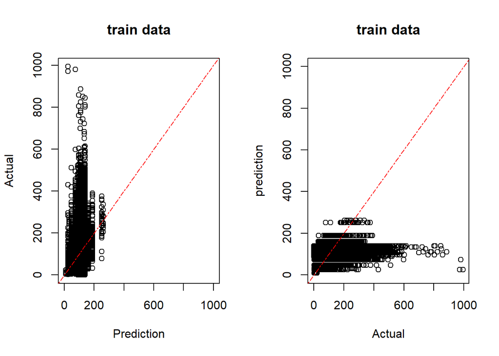

```
## integer(0)
```

```r
plot(PRSA_train$pm2.5, PRSA_train$pred_pm2.5_mean, ylim = c(0, 1000), main = "train data",
     xlab = "Actual", ylab = "prediction") + abline(a=0, b=1, col="red", lty=6)
```

```r
par(mfrow = c(1, 2))
plot(PRSA_test$pred_pm2.5, PRSA_test$pm2.5, xlim = c(0, 1000), main = "test data",
     xlab = "Prediction", ylab = "Actual") + abline(a=0, b=1, col="red", lty=6)
```

```
## integer(0)
```

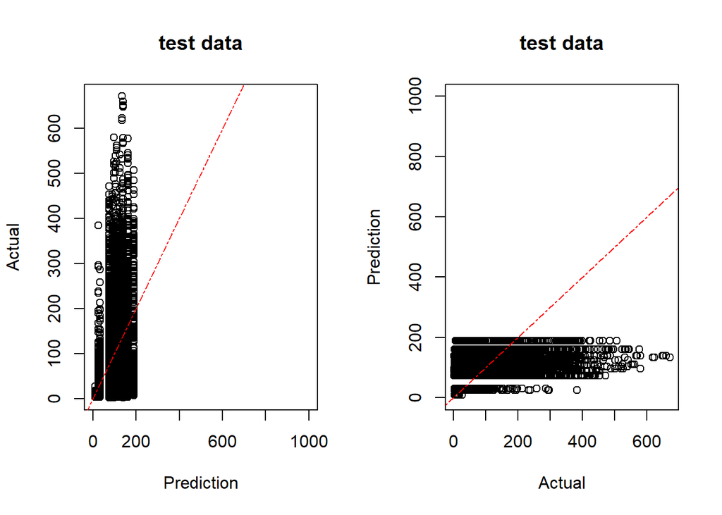

```
## integer(0)
```

```r
plot(PRSA_test$pm2.5, PRSA_test$pred_pm2.5, ylim = c(0, 1000), main = "test data",
     xlab = "Actual", ylab = "Prediction") + abline(a=0, b=1, col="red", lty=6)
```

학습 데이터와 테스트 데이터에서 각각 x축과 y축에 목적변수에 대한 모델의 예측 값을 그린 산점도를 그린다.

학습 데이터와 테스트 데이터에서의 분포에서 볼 수 있듯이, 전반적인 데이터 프레임 자체의 값 안에서 예상치 못한 이상값들이 너무 많았음을 처음에 볼 수 있다.

내가 만든 모델은 이슬점의 median 값을 기준으로 만든 모델이기 때문에 갑작스럽게 커지는 아웃라이어 값들에 대한 예측도는 낮을 수 밖에 없다. 또한 이러한 이유로 실제 예측도도 낮게 나왔던 것으로 생각된다.

이러한 분포는 학습과 테스트 데이터에서 모두 나왔고, 이상적인 모델이 되기 위해서는 실제 값과 예측 값이 비슷해야 하므로 그 기준점으로 y = x 그래프를 그렸다.

## Single variable Model for Classification

# Data load

```r
load('bankruptcy.RData')
head(bankruptcy_train)
```

```
##     corpID          Class Competitiveness Credibility Financial Flexibility
## 162  c0162     Bankruptcy        Negative    Negative              Negative
## 99   c0099 Non-Bankruptcy        Positive    Positive               Average
## 154  c0154     Bankruptcy        Negative    Negative               Average
## 118  c0118 Non-Bankruptcy        Positive     Average               Average
## 34   c0034 Non-Bankruptcy         Average    Positive               Average
## 17   c0017 Non-Bankruptcy        Positive     Average               Average
##     Industrial Risk Management Risk Operating Risk
## 162         Average        Negative       Negative
## 99         Positive        Positive       Positive
## 154        Negative        Negative       Negative
## 118        Positive        Positive       Positive
## 34         Negative        Positive       Positive
## 17         Negative        Negative       Negative
```

```r
head(bankruptcy_test)
```

```
##    corpID          Class Competitiveness Credibility Financial Flexibility
## 11  c0011 Non-Bankruptcy         Average    Positive              Positive
## 15  c0015 Non-Bankruptcy         Average    Positive               Average
## 21  c0021 Non-Bankruptcy         Average     Average              Positive
## 27  c0027 Non-Bankruptcy         Average     Average               Average
## 28  c0028 Non-Bankruptcy         Average     Average               Average
## 30  c0030 Non-Bankruptcy        Positive    Positive              Positive
##    Industrial Risk Management Risk Operating Risk
## 11        Positive        Positive       Positive
## 15        Negative        Negative       Negative
## 21         Average         Average        Average
## 27        Negative        Positive       Negative
## 28        Positive        Negative       Negative
## 30        Negative        Positive       Negative
```

주어진 Data를 load하고, head 함수를 통해 전반적으로 확인한다.

# Checking and changing data’s type

```r
str(bankruptcy_train)
```

```
## 'data.frame':    200 obs. of  8 variables:
##  $ corpID               : chr  "c0162" "c0099" "c0154" "c0118" ...
##  $ Class                : chr  "Bankruptcy" "Non-Bankruptcy" "Bankruptcy" "Non-Bankruptcy" ...
##  $ Competitiveness      : chr  "Negative" "Positive" "Negative" "Positive" ...
##  $ Credibility          : chr  "Negative" "Positive" "Negative" "Average" ...
##  $ Financial Flexibility: chr  "Negative" "Average" "Average" "Average" ...
##  $ Industrial Risk      : chr  "Average" "Positive" "Negative" "Positive" ...
##  $ Management Risk      : chr  "Negative" "Positive" "Negative" "Positive" ...
##  $ Operating Risk       : chr  "Negative" "Positive" "Negative" "Positive" ...
```

```r
bankruptcy_train$Class <- as.factor(bankruptcy_train$Class)
bankruptcy_train$Competitiveness <- as.factor(bankruptcy_train$Competitiveness)
bankruptcy_train$Credibility <- as.factor(bankruptcy_train$Credibility)
bankruptcy_train$`Financial Flexibility` <- as.factor(bankruptcy_train$`Financial Flexibility`)
bankruptcy_train$`Industrial Risk` <- as.factor(bankruptcy_train$`Industrial Risk`)
bankruptcy_train$`Management Risk` <- as.factor(bankruptcy_train$`Management Risk`)
bankruptcy_train$`Operating Risk` <- as.factor(bankruptcy_train$`Operating Risk`)
summary(bankruptcy_train)
```

```
##     corpID                     Class     Competitiveness   Credibility
##  Length:200         Bankruptcy    : 91   Average :42     Average :57
##  Class :character   Non-Bankruptcy:109   Negative:87     Negative:79
##  Mode  :character                        Positive:71     Positive:64
##  Financial Flexibility Industrial Risk Management Risk  Operating Risk
##  Average : 55          Average :69     Average :53     Average :47
##  Negative:103          Negative:70     Negative:95     Negative:87
##  Positive: 42          Positive:61     Positive:52     Positive:66
```

```r
str(bankruptcy_test)
```

```
## 'data.frame':    50 obs. of  8 variables:
##  $ corpID               : chr  "c0011" "c0015" "c0021" "c0027" ...
##  $ Class                : chr  "Non-Bankruptcy" "Non-Bankruptcy" "Non-Bankruptcy" "Non-Bankruptcy" ...
##  $ Competitiveness      : chr  "Average" "Average" "Average" "Average" ...
##  $ Credibility          : chr  "Positive" "Positive" "Average" "Average" ...
##  $ Financial Flexibility: chr  "Positive" "Average" "Positive" "Average" ...
##  $ Industrial Risk      : chr  "Positive" "Negative" "Average" "Negative" ...
##  $ Management Risk      : chr  "Positive" "Negative" "Average" "Positive" ...
##  $ Operating Risk       : chr  "Positive" "Negative" "Average" "Negative" ...
```

```r
bankruptcy_test$Class <- as.factor(bankruptcy_test$Class)
bankruptcy_test$Competitiveness <- as.factor(bankruptcy_test$Competitiveness)
bankruptcy_test$Credibility <- as.factor(bankruptcy_test$Credibility)
bankruptcy_test$`Financial Flexibility` <- as.factor(bankruptcy_test$`Financial Flexibility`)
bankruptcy_test$`Industrial Risk` <- as.factor(bankruptcy_test$`Industrial Risk`)
bankruptcy_test$`Management Risk` <- as.factor(bankruptcy_test$`Management Risk`)
bankruptcy_test$`Operating Risk` <- as.factor(bankruptcy_test$`Operating Risk`)
summary(bankruptcy_test)
```

```
##     corpID                     Class    Competitiveness   Credibility
##  Length:50          Bankruptcy    :16   Average :14     Average :20
##  Class :character   Non-Bankruptcy:34   Negative:16     Negative:15
##  Mode  :character                       Positive:20     Positive:15
##  Financial Flexibility Industrial Risk Management Risk  Operating Risk
##  Average :19           Average :12     Average :16     Average :10
##  Negative:16           Negative:19     Negative:24     Negative:27
##  Positive:15           Positive:19     Positive:10     Positive:13
```

str 함수를 통해서 Data의 ID를 제외한 변수들이 ‘Char’ 형태라는 것을 알 수 있다.

하지만 2~8번 열은 ‘Negative’, ‘Average’, ’Positive’로 각각의 값들이 의미가 있는 명목형 변수이다.

따라서 as.factor 함수를 통해서 형 변환을 하고, 그에 따라 summary로 전반적 분포를 확인한다.

# Q1

```r
aggregate(Competitiveness~Class, bankruptcy_train, summary)[2]
```

```
##   Competitiveness.Average Competitiveness.Negative Competitiveness.Positive
## 1                       4                       87                        0
## 2                      38                        0                       71
```

```r
aggregate(Credibility~Class, bankruptcy_train, summary)[2]
```

```
##   Credibility.Average Credibility.Negative Credibility.Positive
## 1                  14                   74                    3
## 2                  43                    5                   61
```

```r
aggregate(`Financial Flexibility`~Class, bankruptcy_train, summary)[2]
```

```
##   Financial Flexibility.Average Financial Flexibility.Negative
## 1                             4                             86
## 2                            51                             17
##   Financial Flexibility.Positive
## 1                              1
## 2                             41
```

```r
aggregate(`Industrial Risk`~Class, bankruptcy_train, summary)[2]
```

```
##   Industrial Risk.Average Industrial Risk.Negative Industrial Risk.Positive
## 1                      24                       45                       22
## 2                      45                       25                       39
```

```r
aggregate(`Management Risk`~Class, bankruptcy_train, summary)[2]
```

```
##   Management Risk.Average Management Risk.Negative Management Risk.Positive
## 1                      20                       61                       10
## 2                      33                       34                       42
```

```r
aggregate(`Operating Risk`~Class, bankruptcy_train, summary)[2]
```

```
##   Operating Risk.Average Operating Risk.Negative Operating Risk.Positive
## 1                     21                      52                      18
## 2                     26                      35                      48
```

주어진 Data 안에서 각 변수별로 Class와의 연관성을 aggregate 함수를 통해 알아본다.

‘Competitiveness’ 변수에서는 Positive가 0이면 100% 파산이었고, Negative가 0이면 100% 파산이 아니었다.

그 이외의 변수들에서는 적절하게 Positive와 Negative 그리고 Average가 분포된 것을 알 수 있다.

```r
bankruptcy_train[3:8] <- ifelse(bankruptcy_train[3:8] == 'Negative', -1,
                                ifelse(bankruptcy_train[3:8] == 'Average', 0, 1))
bankruptcy_train$eval <- rowSums(bankruptcy_train[3:8])
aggregate(eval ~ Class, bankruptcy_train, mean)
```

```
##            Class      eval
## 1     Bankruptcy -3.857143
## 2 Non-Bankruptcy  1.706422
```

```r
threshold <- -2
bankruptcy_train$prediction <- bankruptcy_train$eval > threshold
head(bankruptcy_train[, c('eval', 'Class', 'prediction')], 10)
```

```
##     eval          Class prediction
## 162   -5     Bankruptcy      FALSE
## 99     5 Non-Bankruptcy       TRUE
## 154   -5     Bankruptcy      FALSE
## 118    4 Non-Bankruptcy       TRUE
## 34     2 Non-Bankruptcy       TRUE
## 17    -2 Non-Bankruptcy      FALSE
## 32     1 Non-Bankruptcy       TRUE
## 96     3 Non-Bankruptcy       TRUE
## 1      3 Non-Bankruptcy       TRUE
## 150   -4     Bankruptcy      FALSE
```

```r
conf.table_train <- table(pred = bankruptcy_train$prediction, actual = bankruptcy_train$Class)
accuracy_train <- sum(diag(conf.table_train)) / sum(conf.table_train)
accuracy_train
```

```
## [1] 0.96
```

```r
bankruptcy_train$ROC <- ifelse(bankruptcy_train$prediction == FALSE, 0, 1)
```

이에 대하여 파산 여부를 파악하는 Model을 만드려고 하는데, 가장 먼저는 각 변수들의 의미를 살펴보았다.

경쟁력, 신용도, 재무 유동성, 산업 위험, 경영 위험, 작업 위험의 변수로 긍정, 부정, 평균에 대해 파산 여부가 주어졌다.

이를 각 변수들에 대하여 폭넓게 이해하기 위하여 주어진 6가지 변수들 모두를 고려한 새로운 변수를 만들어보고자 한다.

긍정과 부정, 평균으로 나누어진 값은 결국 각 변수들에 대하여 기업이 가지고 있는 성과이므로, 각각의 값을 1, -1, 0으로 나눴다.

그리고 구해진 값들에 대하여 rowSums을 통해 각 변수들의 전반적 상태를 수치로 표현하는 새로운 변수 ’eval’을 만들었다.

그 후, threshold 값을 전반적 평균과 비교하여 -2로 설정하고, 이에 따른 정확도를 구한다.

그래서 정확도가 약 96% 정도라는 것을 확인할 수 있었다.

```r
calAUC <- function(predCol, targetCol){
  perf <- performance(prediction(predCol, targetCol), 'auc')
  as.numeric(perf@y.values)
}

calAUC(bankruptcy_train$eval, bankruptcy_train$Class)
```

```
## [1] 0.9911785
```

이에 대하여 AUC를 구하면, 약 99.1%가 나오는 것을 볼 수 있다.

# Q2

```r
bankruptcy_test[3:8] <- ifelse(bankruptcy_test[3:8] == 'Negative', -1,
                               ifelse(bankruptcy_test[3:8] == 'Average', 0, 1))
bankruptcy_test$eval <- rowSums(bankruptcy_test[3:8])
aggregate(eval ~ Class, bankruptcy_test, mean)
```

```
##            Class      eval
## 1     Bankruptcy -4.437500
## 2 Non-Bankruptcy  1.352941
```

```r
threshold <- -2
bankruptcy_test$prediction <- bankruptcy_test$eval > threshold
head(bankruptcy_test[, c('eval', 'Class', 'prediction')], 10)
```

```
##    eval          Class prediction
## 11    5 Non-Bankruptcy       TRUE
## 15   -2 Non-Bankruptcy      FALSE
## 21    1 Non-Bankruptcy       TRUE
## 27   -1 Non-Bankruptcy       TRUE
## 28   -1 Non-Bankruptcy       TRUE
## 30    2 Non-Bankruptcy       TRUE
## 35    0 Non-Bankruptcy       TRUE
## 36    1 Non-Bankruptcy       TRUE
## 42    1 Non-Bankruptcy       TRUE
## 45    1 Non-Bankruptcy       TRUE
```

```r
conf.table_test <- table(pred = bankruptcy_test$prediction, actual = bankruptcy_test$Class)
accuracy_test <- sum(diag(conf.table_test)) / sum(conf.table_test)
accuracy_test
```

```
## [1] 0.94
```

```r
calAUC(bankruptcy_test$eval, bankruptcy_test$Class)
```

```
## [1] 0.9917279
```

```r
bankruptcy_test$ROC <- ifelse(bankruptcy_test$prediction == FALSE, 0, 1)
```

앞선 train data를 통해 구했던 그 과정을 test data에 적용시킨다.

동일한 방식으로 긍정, 부정, 평균을 각각 1, -1, 0으로 값을 변경하고, 그에 따른 변수의 합을 구한다.

이를 통해 test data에서는 비록 train data보다 조금 낮긴 했지만, 94%의 정확도를 얻을 수 있었다.

또한 AUC를 구하게 되면, 99.2%의 결과를 확인할 수 있다.

# Q3

```r
accuracy_train
```

```
## [1] 0.96
```

```r
accuracy_test
```

```
## [1] 0.94
```

train과 test data를 통해 구한 정확도는 각각 96%, 94%라는 것을 확인할 수 있다.

따라서 이 상황에서는 train data의 예측도가 test data 보다 높은 것을 알 수 있다.

일반적으로 과적합은 train data에서만 높은 예측 결과를 보이고, test data에서는 그렇지 못한 것을 의미하는데, 이 예측값은 둘의 차이가 거의 나지 않는다고 판단되기 때문에 과적합이라고 보기엔 어려울 것 같다.

# Q4

```r
threshold <- -6
bankruptcy_train$prediction <- bankruptcy_train$eval > threshold
conf.table_train <- table(pred = bankruptcy_train$prediction, actual = bankruptcy_train$Class)
precision_train1 <- conf.table_train[2, 2] / sum(conf.table_train[2, ])
recall_train1 <- conf.table_train[2, 2] / sum(conf.table_train[, 2])

threshold <- -5
bankruptcy_train$prediction <- bankruptcy_train$eval > threshold
conf.table_train <- table(pred = bankruptcy_train$prediction, actual = bankruptcy_train$Class)
precision_train2 <- conf.table_train[2, 2] / sum(conf.table_train[2, ])
recall_train2 <- conf.table_train[2, 2] / sum(conf.table_train[, 2])

threshold <- -4
bankruptcy_train$prediction <- bankruptcy_train$eval > threshold
conf.table_train <- table(pred = bankruptcy_train$prediction, actual = bankruptcy_train$Class)
precision_train3 <- conf.table_train[2, 2] / sum(conf.table_train[2, ])
recall_train3 <- conf.table_train[2, 2] / sum(conf.table_train[, 2])

threshold <- -3
bankruptcy_train$prediction <- bankruptcy_train$eval > threshold
conf.table_train <- table(pred = bankruptcy_train$prediction, actual = bankruptcy_train$Class)
precision_train4 <- conf.table_train[2, 2] / sum(conf.table_train[2, ])
recall_train4 <- conf.table_train[2, 2] / sum(conf.table_train[, 2])

threshold <- -2
bankruptcy_train$prediction <- bankruptcy_train$eval > threshold
conf.table_train <- table(pred = bankruptcy_train$prediction, actual = bankruptcy_train$Class)
precision_train5 <- conf.table_train[2, 2] / sum(conf.table_train[2, ])
recall_train5 <- conf.table_train[2, 2] / sum(conf.table_train[, 2])

threshold <- -1
bankruptcy_train$prediction <- bankruptcy_train$eval > threshold
conf.table_train <- table(pred = bankruptcy_train$prediction, actual = bankruptcy_train$Class)
precision_train6 <- conf.table_train[2, 2] / sum(conf.table_train[2, ])
recall_train6 <- conf.table_train[2, 2] / sum(conf.table_train[, 2])

threshold <- 0
bankruptcy_train$prediction <- bankruptcy_train$eval > threshold
conf.table_train <- table(pred = bankruptcy_train$prediction, actual = bankruptcy_train$Class)
precision_train7 <- conf.table_train[2, 2] / sum(conf.table_train[2, ])
recall_train7 <- conf.table_train[2, 2] / sum(conf.table_train[, 2])

threshold <- 1
bankruptcy_train$prediction <- bankruptcy_train$eval > threshold
conf.table_train <- table(pred = bankruptcy_train$prediction, actual = bankruptcy_train$Class)
precision_train8 <- conf.table_train[2, 2] / sum(conf.table_train[2, ])
recall_train8 <- conf.table_train[2, 2] / sum(conf.table_train[, 2])

threshold <- 2
bankruptcy_train$prediction <- bankruptcy_train$eval > threshold
conf.table_train <- table(pred = bankruptcy_train$prediction, actual = bankruptcy_train$Class)
precision_train9 <- conf.table_train[2, 2] / sum(conf.table_train[2, ])
recall_train9 <- conf.table_train[2, 2] / sum(conf.table_train[, 2])

threshold <- 3
bankruptcy_train$prediction <- bankruptcy_train$eval > threshold
conf.table_train <- table(pred = bankruptcy_train$prediction, actual = bankruptcy_train$Class)
precision_train10 <- conf.table_train[2, 2] / sum(conf.table_train[2, ])
recall_train10 <- conf.table_train[2, 2] / sum(conf.table_train[, 2])

threshold <- 4
bankruptcy_train$prediction <- bankruptcy_train$eval > threshold
conf.table_train <- table(pred = bankruptcy_train$prediction, actual = bankruptcy_train$Class)
precision_train11 <- conf.table_train[2, 2] / sum(conf.table_train[2, ])
recall_train11 <- conf.table_train[2, 2] / sum(conf.table_train[, 2])

threshold <- 5
bankruptcy_train$prediction <- bankruptcy_train$eval > threshold
conf.table_train <- table(pred = bankruptcy_train$prediction, actual = bankruptcy_train$Class)
precision_train12 <- conf.table_train[2, 2] / sum(conf.table_train[2, ])
recall_train12 <- conf.table_train[2, 2] / sum(conf.table_train[, 2])
```

threshold를 -6부터 5까지 설정하여 그에 따른 precision과 recall을 구한다.

```r
precision_recall <- data.frame(precision = c(precision_train1, precision_train2, precision_train3,
                                             precision_train4, precision_train5, precision_train6,
                                             precision_train7, precision_train8, precision_train9,
                                             precision_train10, precision_train11, precision_train12),
                              recall = c(recall_train1, recall_train2, recall_train3, recall_train4,
                                         recall_train5, recall_train6, recall_train7, recall_train8,
                                         recall_train9, recall_train10, recall_train11, recall_train12),
                              threshold = c(-6:5))

precision_recall
```

```
##    precision      recall threshold
## 1  0.5589744 1.000000000        -6
## 2  0.6411765 1.000000000        -5
## 3  0.7841727 1.000000000        -4
## 4  0.8709677 0.990825688        -3
## 5  0.9902913 0.935779817        -2
## 6  0.9894737 0.862385321        -1
## 7  1.0000000 0.761467890         0
## 8  1.0000000 0.596330275         1
## 9  1.0000000 0.293577982         2
## 10 1.0000000 0.174311927         3
## 11 1.0000000 0.082568807         4
## 12 1.0000000 0.009174312         5
```

각각의 threshold에 맞게 percision과 recall을 넣은 새로운 데이터 프레임을 만든다.

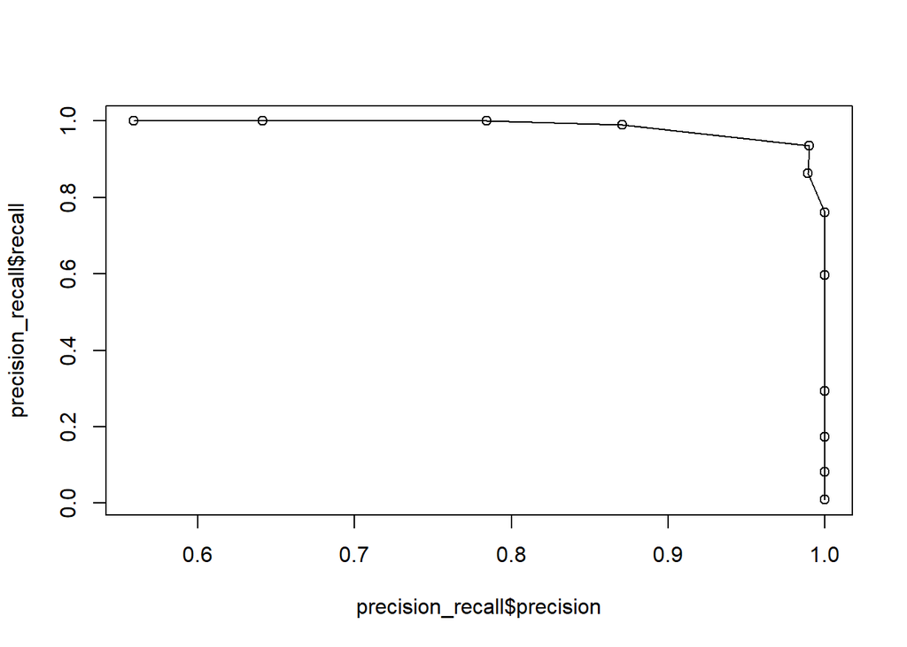

```
## integer(0)
```

```r
plot(precision_recall$precision, precision_recall$recall) +
  lines(precision_recall$precision, precision_recall$recall)
```

만들어 놓은 데이터 프레임으로 그래프를 그리면 다음과 같은 결과를 얻을 수 있다.

```r
threshold <- -6
bankruptcy_test$prediction <- bankruptcy_test$eval > threshold
conf.table_test <- table(pred = bankruptcy_test$prediction, actual = bankruptcy_test$Class)
precision_test1 <- conf.table_test[2, 2] / sum(conf.table_test[2, ])
recall_test1 <- conf.table_test[2, 2] / sum(conf.table_test[, 2])

threshold <- -5
bankruptcy_test$prediction <- bankruptcy_test$eval > threshold
conf.table_test <- table(pred = bankruptcy_test$prediction, actual = bankruptcy_test$Class)
precision_test2 <- conf.table_test[2, 2] / sum(conf.table_test[2, ])
recall_test2 <- conf.table_test[2, 2] / sum(conf.table_test[, 2])

threshold <- -4
bankruptcy_test$prediction <- bankruptcy_test$eval > threshold
conf.table_test <- table(pred = bankruptcy_test$prediction, actual = bankruptcy_test$Class)
precision_test3 <- conf.table_test[2, 2] / sum(conf.table_test[2, ])
recall_test3 <- conf.table_test[2, 2] / sum(conf.table_test[, 2])

threshold <- -3
bankruptcy_test$prediction <- bankruptcy_test$eval > threshold
conf.table_test <- table(pred = bankruptcy_test$prediction, actual = bankruptcy_test$Class)
precision_test4 <- conf.table_test[2, 2] / sum(conf.table_test[2, ])
recall_test4 <- conf.table_test[2, 2] / sum(conf.table_test[, 2])

threshold <- -2
bankruptcy_test$prediction <- bankruptcy_test$eval > threshold
conf.table_test <- table(pred = bankruptcy_test$prediction, actual = bankruptcy_test$Class)
precision_test5 <- conf.table_test[2, 2] / sum(conf.table_test[2, ])
recall_test5 <- conf.table_test[2, 2] / sum(conf.table_test[, 2])

threshold <- -1
bankruptcy_test$prediction <- bankruptcy_test$eval > threshold
conf.table_test <- table(pred = bankruptcy_test$prediction, actual = bankruptcy_test$Class)
precision_test6 <- conf.table_test[2, 2] / sum(conf.table_test[2, ])
recall_test6 <- conf.table_test[2, 2] / sum(conf.table_test[, 2])

threshold <- 0
bankruptcy_test$prediction <- bankruptcy_test$eval > threshold
conf.table_test <- table(pred = bankruptcy_test$prediction, actual = bankruptcy_test$Class)
precision_test7 <- conf.table_test[2, 2] / sum(conf.table_test[2, ])
recall_test7 <- conf.table_test[2, 2] / sum(conf.table_test[, 2])

threshold <- 1
bankruptcy_test$prediction <- bankruptcy_test$eval > threshold
conf.table_test <- table(pred = bankruptcy_test$prediction, actual = bankruptcy_test$Class)
precision_test8 <- conf.table_test[2, 2] / sum(conf.table_test[2, ])
recall_test8 <- conf.table_test[2, 2] / sum(conf.table_test[, 2])

threshold <- 2
bankruptcy_test$prediction <- bankruptcy_test$eval > threshold
conf.table_test <- table(pred = bankruptcy_test$prediction, actual = bankruptcy_test$Class)
precision_test9 <- conf.table_test[2, 2] / sum(conf.table_test[2, ])
recall_test9 <- conf.table_test[2, 2] / sum(conf.table_test[, 2])

threshold <- 3
bankruptcy_test$prediction <- bankruptcy_test$eval > threshold
conf.table_test <- table(pred = bankruptcy_test$prediction, actual = bankruptcy_test$Class)
precision_test10 <- conf.table_test[2, 2] / sum(conf.table_test[2, ])
recall_test10 <- conf.table_test[2, 2] / sum(conf.table_test[, 2])

threshold <- 4
bankruptcy_test$prediction <- bankruptcy_test$eval > threshold
conf.table_test <- table(pred = bankruptcy_test$prediction, actual = bankruptcy_test$Class)
precision_test11 <- conf.table_test[2, 2] / sum(conf.table_test[2, ])
recall_test11 <- conf.table_test[2, 2] / sum(conf.table_test[, 2])

threshold <- 5
bankruptcy_test$prediction <- bankruptcy_test$eval > threshold
conf.table_test <- table(pred = bankruptcy_test$prediction, actual = bankruptcy_test$Class)
precision_test12 <- conf.table_test[2, 2] / sum(conf.table_test[2, ])
recall_test12 <- conf.table_test[2, 2] / sum(conf.table_test[, 2])
```

동일한 방식으로 test data에도 precision과 recall을 구한다.

```r
precision_recall_test <- data.frame(precision = c(precision_test1, precision_test2, precision_test3,
                                                 precision_test4, precision_test5, precision_test6,
                                                 precision_test7, precision_test8, precision_test9,
                                                 precision_test10, precision_test11, precision_test12),
                                   recall = c(recall_test1, recall_test2, recall_test3, recall_test4,
                                              recall_test5, recall_test6, recall_test7, recall_test8,
                                              recall_test9, recall_test10, recall_test11, recall_test12),
                                   threshold = c(-6:5))

precision_recall_test
```

```
##    precision     recall threshold
## 1  0.7555556 1.00000000        -6
## 2  0.7906977 1.00000000        -5
## 3  0.9189189 1.00000000        -4
## 4  0.9428571 0.97058824        -3
## 5  1.0000000 0.91176471        -2
## 6  1.0000000 0.79411765        -1
## 7  1.0000000 0.70588235         0
## 8  1.0000000 0.41176471         1
## 9  1.0000000 0.26470588         2
## 10 1.0000000 0.17647059         3
## 11 1.0000000 0.08823529         4
## 12 1.0000000 0.02941176         5
```

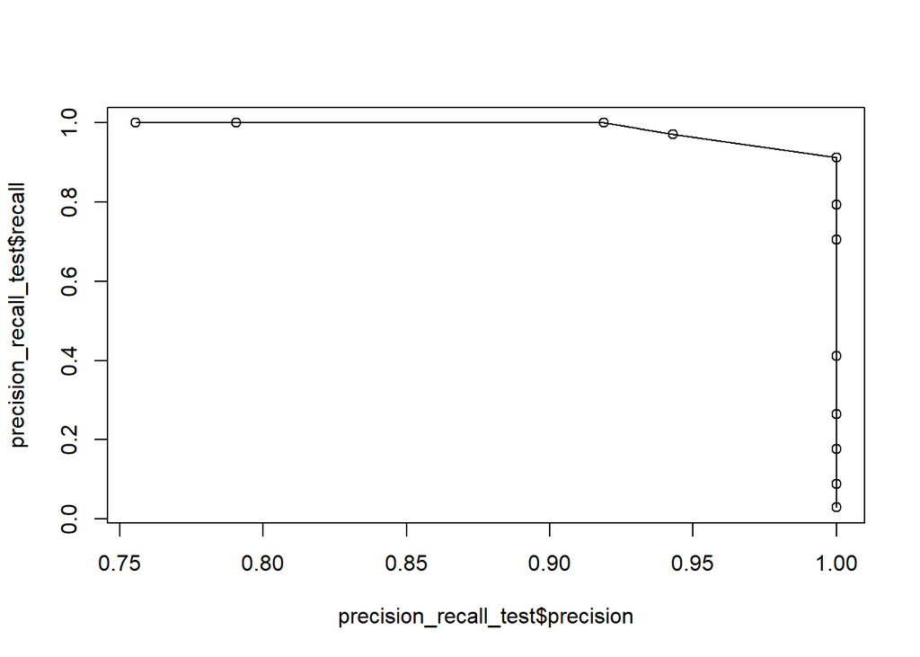

```
## integer(0)
```

```r
plot(precision_recall_test$precision, precision_recall_test$recall) +
  lines(precision_recall_test$precision, precision_recall_test$recall)
```

구했던 내용을 바탕으로 하나의 데이터 프레임으로 만들고, 그래프를 그린다.

test 데이터에서는 train 데이터와는 다르게, threshold가 -4일 때, precision과 recall이 최적의 값임을 볼 수 있다.

# Q5

```r
precision_recall$f1 <- 2 * ((precision_recall$precision * precision_recall$recall) /
                              (precision_recall$precision + precision_recall$recall))
precision_recall[order(precision_recall$f1, decreasing = T), ]
```

```
##    precision      recall threshold         f1
## 5  0.9902913 0.935779817        -2 0.96226415
## 4  0.8709677 0.990825688        -3 0.92703863
## 6  0.9894737 0.862385321        -1 0.92156863
## 3  0.7841727 1.000000000        -4 0.87903226
## 7  1.0000000 0.761467890         0 0.86458333
## 2  0.6411765 1.000000000        -5 0.78136201
## 8  1.0000000 0.596330275         1 0.74712644
## 1  0.5589744 1.000000000        -6 0.71710526
## 9  1.0000000 0.293577982         2 0.45390071
## 10 1.0000000 0.174311927         3 0.29687500
## 11 1.0000000 0.082568807         4 0.15254237
## 12 1.0000000 0.009174312         5 0.01818182
```

```r
precision_recall_test$f1 <- 2 * ((precision_recall_test$precision * precision_recall_test$recall) /
                                  (precision_recall_test$precision + precision_recall_test$recall))
precision_recall_test[order(precision_recall_test$f1, decreasing = T), ]
```

```
##    precision     recall threshold         f1
## 3  0.9189189 1.00000000        -4 0.95774648
## 4  0.9428571 0.97058824        -3 0.95652174
## 5  1.0000000 0.91176471        -2 0.95384615
## 6  1.0000000 0.79411765        -1 0.88524590
## 2  0.7906977 1.00000000        -5 0.88311688
## 1  0.7555556 1.00000000        -6 0.86075949
## 7  1.0000000 0.70588235         0 0.82758621
## 8  1.0000000 0.41176471         1 0.58333333
## 9  1.0000000 0.26470588         2 0.41860465
## 10 1.0000000 0.17647059         3 0.30000000
## 11 1.0000000 0.08823529         4 0.16216216
## 12 1.0000000 0.02941176         5 0.05714286
```

precision과 recall 그리고 threshold로 구성된 데이터 프레임에 주어진 조건에 따른 f1 변수를 추가한다.

이를 통해 구해진 f1 변수의 값을 내림차순으로 정리한다.

결국 train 데이터에서는 -2가, test 데이터에서는 -4가 최적의 threshold 임을 확인할 수 있다.

# Q6

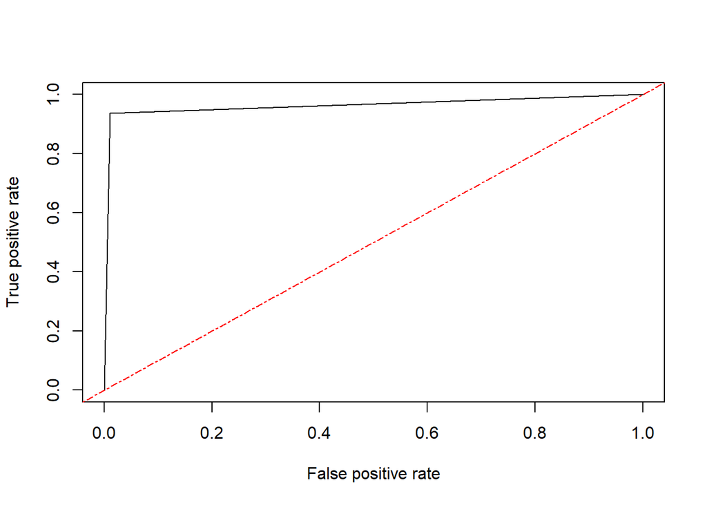

```
## integer(0)
```

```r
bankruptcy_train$Class <- ifelse(bankruptcy_train$Class == 'Bankruptcy', 0, 1)

plot(performance(prediction(bankruptcy_train$ROC, bankruptcy_train$Class), 'tpr', 'fpr')) +
  abline(a = 0, b = 1, col = 'red', lty = 6)
```

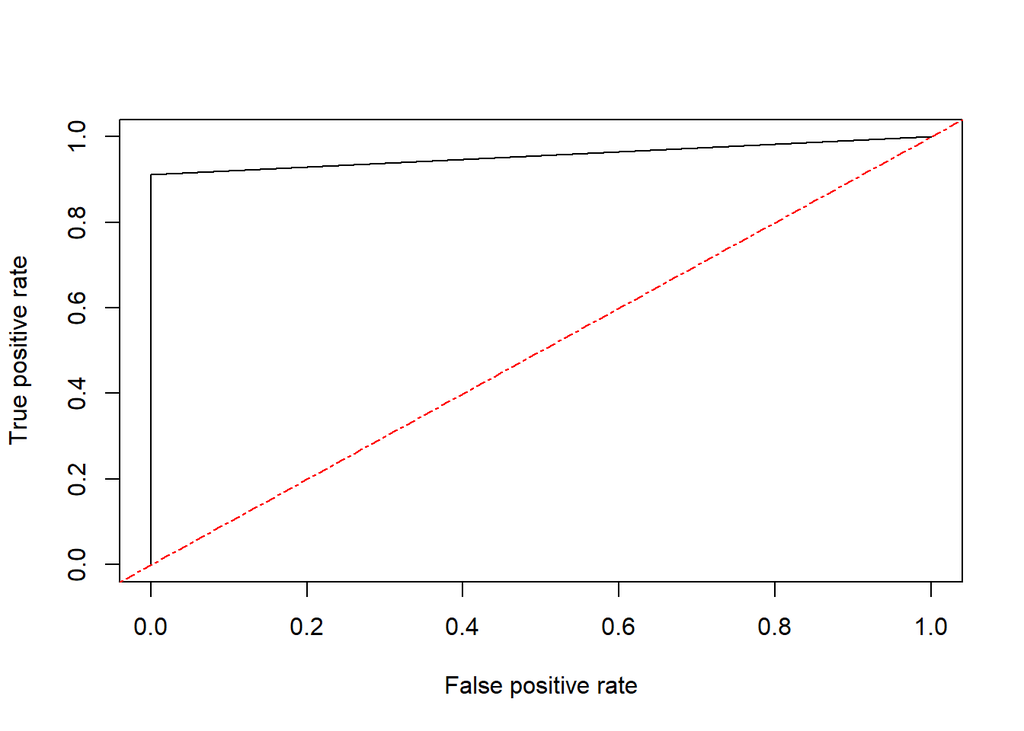

```
## integer(0)
```

```r
bankruptcy_test$Class <- ifelse(bankruptcy_test$Class == 'Bankruptcy', 0, 1)

plot(performance(prediction(bankruptcy_test$ROC, bankruptcy_test$Class), 'tpr', 'fpr')) +
  abline(a = 0, b = 1, col = 'red', lty = 6)
```

train과 test 데이터에서의 ROC 커브를 그려본다.

ROCR 패키지를 통해 예측값과 실제 값에 대한 ROC를 그려보고, y = x 그래프도 함께 그려서 전반적으로 비교해본다.

이를 통해 TPR에 값에 따라 AUC 값이 최대가 될 수 있는 것을 알 수 있다.

# Q7

```r
threshold <- -6
bankruptcy_train$prediction <- bankruptcy_train$eval > threshold
conf.table <- table(pred = bankruptcy_train$prediction, actual = bankruptcy_train$Class)
accuracy_train1 <- sum(diag(conf.table)) / sum(conf.table)

threshold <- -5
bankruptcy_train$prediction <- bankruptcy_train$eval > threshold
conf.table <- table(pred = bankruptcy_train$prediction, actual = bankruptcy_train$Class)
accuracy_train2 <- sum(diag(conf.table)) / sum(conf.table)

threshold <- -4
bankruptcy_train$prediction <- bankruptcy_train$eval > threshold
conf.table <- table(pred = bankruptcy_train$prediction, actual = bankruptcy_train$Class)
accuracy_train3 <- sum(diag(conf.table)) / sum(conf.table)

threshold <- -3
bankruptcy_train$prediction <- bankruptcy_train$eval > threshold
conf.table <- table(pred = bankruptcy_train$prediction, actual = bankruptcy_train$Class)
accuracy_train4 <- sum(diag(conf.table)) / sum(conf.table)

threshold <- -2
bankruptcy_train$prediction <- bankruptcy_train$eval > threshold
conf.table <- table(pred = bankruptcy_train$prediction, actual = bankruptcy_train$Class)
accuracy_train5 <- sum(diag(conf.table)) / sum(conf.table)

threshold <- -1
bankruptcy_train$prediction <- bankruptcy_train$eval > threshold
conf.table <- table(pred = bankruptcy_train$prediction, actual = bankruptcy_train$Class)
accuracy_train6 <- sum(diag(conf.table)) / sum(conf.table)

threshold <- 0
bankruptcy_train$prediction <- bankruptcy_train$eval > threshold
conf.table <- table(pred = bankruptcy_train$prediction, actual = bankruptcy_train$Class)
accuracy_train7 <- sum(diag(conf.table)) / sum(conf.table)

threshold <- 1
bankruptcy_train$prediction <- bankruptcy_train$eval > threshold
conf.table <- table(pred = bankruptcy_train$prediction, actual = bankruptcy_train$Class)
accuracy_train8 <- sum(diag(conf.table)) / sum(conf.table)

threshold <- 2
bankruptcy_train$prediction <- bankruptcy_train$eval > threshold
conf.table <- table(pred = bankruptcy_train$prediction, actual = bankruptcy_train$Class)
accuracy_train9 <- sum(diag(conf.table)) / sum(conf.table)

threshold <- 3
bankruptcy_train$prediction <- bankruptcy_train$eval > threshold
conf.table <- table(pred = bankruptcy_train$prediction, actual = bankruptcy_train$Class)
accuracy_train10 <- sum(diag(conf.table)) / sum(conf.table)

threshold <- 4
bankruptcy_train$prediction <- bankruptcy_train$eval > threshold
conf.table <- table(pred = bankruptcy_train$prediction, actual = bankruptcy_train$Class)
accuracy_train11 <- sum(diag(conf.table)) / sum(conf.table)

threshold <- 5
bankruptcy_train$prediction <- bankruptcy_train$eval > threshold
conf.table <- table(pred = bankruptcy_train$prediction, actual = bankruptcy_train$Class)
accuracy_train12 <- sum(diag(conf.table)) / sum(conf.table)

accuracy_train_df <- data.frame(threshold = c(-6:5),
                                accuracy = c(accuracy_train1, accuracy_train2, accuracy_train3,
                                             accuracy_train4, accuracy_train5, accuracy_train6,
                                             accuracy_train7, accuracy_train8, accuracy_train9,
                                             accuracy_train10, accuracy_train11, accuracy_train12))
accuracy_train_df[order(accuracy_train_df$accuracy, decreasing = T), ]
```

```
##    threshold accuracy
## 5         -2    0.960
## 6         -1    0.920
## 4         -3    0.915
## 7          0    0.870
## 3         -4    0.850
## 8          1    0.780
## 2         -5    0.695
## 9          2    0.615
## 1         -6    0.570
## 10         3    0.550
## 11         4    0.500
## 12         5    0.460
```

threshold에 따라 train 데이터의 accuracy를 구하고, 데이터 프레임으로 만들었다.

이를 통해 train 데이터에서는 -2 일때, 가장 최댓값이 나오는 것을 알 수 있다.

```r
threshold <- -6
bankruptcy_test$prediction <- bankruptcy_test$eval > threshold
conf.table <- table(pred = bankruptcy_test$prediction, actual = bankruptcy_test$Class)
accuracy_test1 <- sum(diag(conf.table)) / sum(conf.table)

threshold <- -5
bankruptcy_test$prediction <- bankruptcy_test$eval > threshold
conf.table <- table(pred = bankruptcy_test$prediction, actual = bankruptcy_test$Class)
accuracy_test2 <- sum(diag(conf.table)) / sum(conf.table)

threshold <- -4
bankruptcy_test$prediction <- bankruptcy_test$eval > threshold
conf.table <- table(pred = bankruptcy_test$prediction, actual = bankruptcy_test$Class)
accuracy_test3 <- sum(diag(conf.table)) / sum(conf.table)

threshold <- -3
bankruptcy_test$prediction <- bankruptcy_test$eval > threshold
conf.table <- table(pred = bankruptcy_test$prediction, actual = bankruptcy_test$Class)
accuracy_test4 <- sum(diag(conf.table)) / sum(conf.table)

threshold <- -2
bankruptcy_test$prediction <- bankruptcy_test$eval > threshold
conf.table <- table(pred = bankruptcy_test$prediction, actual = bankruptcy_test$Class)
accuracy_test5 <- sum(diag(conf.table)) / sum(conf.table)

threshold <- -1
bankruptcy_test$prediction <- bankruptcy_test$eval > threshold
conf.table <- table(pred = bankruptcy_test$prediction, actual = bankruptcy_test$Class)
accuracy_test6 <- sum(diag(conf.table)) / sum(conf.table)

threshold <- 0
bankruptcy_test$prediction <- bankruptcy_test$eval > threshold
conf.table <- table(pred = bankruptcy_test$prediction, actual = bankruptcy_test$Class)
accuracy_test7 <- sum(diag(conf.table)) / sum(conf.table)

threshold <- 1
bankruptcy_test$prediction <- bankruptcy_test$eval > threshold
conf.table <- table(pred = bankruptcy_test$prediction, actual = bankruptcy_test$Class)
accuracy_test8 <- sum(diag(conf.table)) / sum(conf.table)

threshold <- 2
bankruptcy_test$prediction <- bankruptcy_test$eval > threshold
conf.table <- table(pred = bankruptcy_test$prediction, actual = bankruptcy_test$Class)
accuracy_test9 <- sum(diag(conf.table)) / sum(conf.table)

threshold <- 3
bankruptcy_test$prediction <- bankruptcy_test$eval > threshold
conf.table <- table(pred = bankruptcy_test$prediction, actual = bankruptcy_test$Class)
accuracy_test10 <- sum(diag(conf.table)) / sum(conf.table)

threshold <- 4
bankruptcy_test$prediction <- bankruptcy_test$eval > threshold
conf.table <- table(pred = bankruptcy_test$prediction, actual = bankruptcy_test$Class)
accuracy_test11 <- sum(diag(conf.table)) / sum(conf.table)

threshold <- 5
bankruptcy_test$prediction <- bankruptcy_test$eval > threshold
conf.table <- table(pred = bankruptcy_test$prediction, actual = bankruptcy_test$Class)
accuracy_test12 <- sum(diag(conf.table)) / sum(conf.table)

accuracy_test_df <- data.frame(threshold = c(-6:5),
                               accuracy = c(accuracy_test1, accuracy_test2, accuracy_test3,
                                            accuracy_test4, accuracy_test5, accuracy_test6,
                                            accuracy_test7, accuracy_test8, accuracy_test9,
                                            accuracy_test10, accuracy_test11, accuracy_test12))
accuracy_test_df[order(accuracy_test_df$accuracy, decreasing = T), ]
```

```
##    threshold accuracy
## 3         -4     0.94
## 4         -3     0.94
## 5         -2     0.94
## 6         -1     0.86
## 2         -5     0.82
## 7          0     0.80
## 1         -6     0.78
## 8          1     0.60
## 9          2     0.50
## 10         3     0.44
## 11         4     0.38
## 12         5     0.34
```

동일한 방식으로 test data에서의 accuracy를 구하면, -4, -3, -2 일때 최댓값이 나옴을 볼 수 있다.

# Q8

앞선 Regression 문제와 동일하게 16학번 조예성, 17학번 이지현 학우님과 서로의 예측 모델을 비교했다.

두 학우 모두는 Competitiveness 변수를 기반으로 예측 모델을 만들었다. 그리고 이 모델의 결과는 완벽히 일치하는 1이 나오는 결과를 보였다.

상대적으로 내가 만든 모델은 1에 수렴하긴 했지만, 1보다는 작은 약 99% 정도의 예측도를 보였다.

그나마 조금 평가해볼 수 있는 것은 내가 만들었던 모델은 주어진 6개의 변수 모두를 활용하여 하나의 단일 변수로 만들어 적용했다. 이를 통해 기업의 하나의 측면만을 통해 파산 여부를 파악하는 것이 아니라, 전반적인 경영 및 재무 상태 등과 같은 다양한 변수들을 고려했으므로 나름의 의미가 있다고 생각이 되었다.